# Pricing Decision-Support for Airbnb Hosts in Vaud

Machine Learning 1 - Group Project

Pascal Ingold · Timon Reichmuth · Davide Gualdani

24 Mai 2026

Sprint 24.05.2026

ToDos backlog:

- alles nocheinmal drüberlesen.
- tuning wieder reaktivieren

# 1 Introduction

## 1.1 Business Case

We propose a data-driven pricing decision-support system for Airbnb hosts in the Canton of Vaud, providing market-aligned price recommendations based on listing characteristics. The tool targets both new and existing hosts, using inputs such as room type, guest capacity, availability, ratings, and superhost status. Six machine learning tools are used: a linear Model(LM), a generalised linear model using poisson (GLM), a generalized linear Model using binomial (GLM), a general additive model (GAM), a support vector machine (SVM) and a Neural Network (ANN), are applied to identify key price drivers and generate accurate predictions. The objective is to balance revenue and occupancy, helping hosts understand their market value. A key feature is interpretability, enabling users to see why a certain price is recommended. From a business perspective, the system aims to increase booking rates, reduce price dispersion, and improve host satisfaction. The model is tailored to the Canton of Vaud to capture regional economic effects.

## 1.2 Research Questions

Several questions can be derived from the business case. These questions are intended to help us examine pricing dynamics and facilitate the development of a pricing strategy for Airbnb-Hosts.

- RQ1 - First, **we need to determine which factors influence guests’ willingness to pay**. Furthermore, the nature of this influence is, of course, central to our analysis.
- RQ2 - Once these factors are identified, a second question immediately arises: **to what extent can these factors be used to predict whether the prices of a rental property are justified?**

Willingness to pay is actually the central variable here. However, it is not easy to measure, which is why a different approach must be taken. The approach we have chosen stems from the idea that the market generally functions well and that landlords intuitively already align with willingness to pay. As a result, the existing price for a rental property can also be assumed to be the price that tenants are willing to pay. Any deviations are offset in our subsequent calculations by the large number of observations. Thus, on average, the actual price will correspond to the price that tenants are willing to pay.

## 1.3 Hypothesis

- H1: When host-centered indicators improve, tenants’ willingness to pay increases.
- H2: When location-centered indicators improve, tenants’ willingness to pay increases.

Host-centered indicators are those that relate to the host’s performance, such as ratings or Superhost status. In contrast, location-centered indicators are those that relate to factors such as the size of the rental property. With these hypothesis, we are able to operationalize the research questions in such a way, that we can investigate the underlying relations.

# 2 Data Preparation

In a first step we need to load the relevant packages. Following that we load all the datasets that are relevant to us.

```r
library(tidyverse)
library(janitor)
library(mgcv)
library(e1071)
library(nnet)
library(pROC)
library(Metrics)
library(performance)
library(broom)
library(kableExtra)
library(stringr)
library(ggplot2)
library(patchwork)
library(knitr)
library(performance)
library(naniar)
library(visdat)
library(neuralnet)
library(leaflet)
library(leaflet.extras)
library(patchwork)


theme_set(theme_minimal())

path_listings <- "./Data_Vaud_all/listings-2.csv"
d.raw_data_listings <- read.csv(path_listings, header = TRUE)
```

Cleaning the Airbnb-Listings Data. We keep only the variables needed for our project. We reduce the amount of variables to exact 20, according to the requirements by our lecturers.

```r
d.airbnb_listings <- d.raw_data_listings %>%
  clean_names()

d.listings_clean <- d.airbnb_listings %>%
  mutate(
    price = str_remove_all(price, "\\$|,"),
    price = as.numeric(price),
    host_is_superhost = ifelse(host_is_superhost %in% c("t", "TRUE", "1"), 1, 0),
    room_type = as.factor(room_type),
    property_type = as.factor(property_type),
    host_response_rate = as.numeric(sub("%", "", host_response_rate)),
    host_acceptance_rate = as.numeric(sub("%", "", host_acceptance_rate)),
    host_is_superhost = ifelse(host_is_superhost == 1, TRUE, FALSE)
  ) %>%
  filter(!is.na(price), price > 0)


d.listings_clean <- d.listings_clean %>%
  select(
    -id, -host_id, -host_listings_count, -host_total_listings_count, -listing_url, -scrape_id, -last_scraped,
    -source, -name, -description, -maximum_nights, -first_review, -last_review, -calculated_host_listings_count, -host_since, -availability_365, -estimated_revenue_l365d,
    -neighborhood_overview, -picture_url, -host_url, -host_name, -host_location,
    -host_about, -host_thumbnail_url, -host_picture_url, -host_neighbourhood,
    -neighbourhood, -neighbourhood_cleansed, -bathrooms_text, -amenities,
    -minimum_minimum_nights, -maximum_minimum_nights, -minimum_maximum_nights,
    -maximum_maximum_nights, -minimum_nights_avg_ntm, -maximum_nights_avg_ntm,
    -calendar_updated, -has_availability, -availability_30, -availability_60,
    -availability_90, -calendar_last_scraped, -number_of_reviews_ltm, -number_of_reviews_l30d,
    -availability_eoy, -number_of_reviews_ly, -review_scores_accuracy, -review_scores_cleanliness,
    -review_scores_checkin, -review_scores_communication, -review_scores_location,
    -license, -instant_bookable, -calculated_host_listings_count_entire_homes, -calculated_host_listings_count_private_rooms,
    -calculated_host_listings_count_shared_rooms, -reviews_per_month, -bedrooms, -review_scores_value
  )
```

According to the requirements for this paper, the dataset is limited to a maximum of 20 variables. To meet this specification, we have removed columns from the dataset that will not be used in our analysis. Consequently, `d.listings_clean` is our final, cleaned dataset, which we will use to run all subsequent models.

Subsequently, we calculated several additional features to include them as permanent columns in the dataset, ensuring they do not have to be recomputed for each analysis. These include: the log-transformed price, as price data is typically heavily right-skewed and thus not suitable for Gaussian Models, the price per guest (total price divided by the number of guests accommodated), a boolean indicator for high demand, and a binary variable identifying whether the price exceeds the median.

```r
d.airbnb_listings_feat <- d.listings_clean %>%
  mutate(
    log_price = log(price),
    price_per_guest = price / pmax(accommodates, 1),
    high_demand = ifelse(estimated_occupancy_l365d > 200, 1, 0),
    price_high = as.integer(price > median(price, na.rm = TRUE))
  )
```

# 3 Understanding the Data

To inform our modelling choices, we briefly walk through how the data is structured e.g. with distributions, variable types, and edge cases. Airbnb already knows this data well, so we keep the commentary short and focus on what actually matters for the models that follow.

During our exploratory data analysis, we identified one *Private room* listing with an unrealistically high price of 2’147’483’647 CHF. We excluded this single observation from our dataset as it is an extreme outlier that does not reflect the true market conditions and would negatively skew our predictive models.

```r
# This keeps everything except the row that is a Private room and costs more than 100000
d.airbnb_listings_feat <- d.airbnb_listings_feat %>%
  filter(!(room_type == "Private room" & price > 100000))
```

In addition to the one outlier we wanted to remove one NA specifically, as this should be a Boolean.

```r
d.airbnb_listings_feat <- d.airbnb_listings_feat %>%
  filter(!host_has_profile_pic == "")
```

## 3.1 Prices

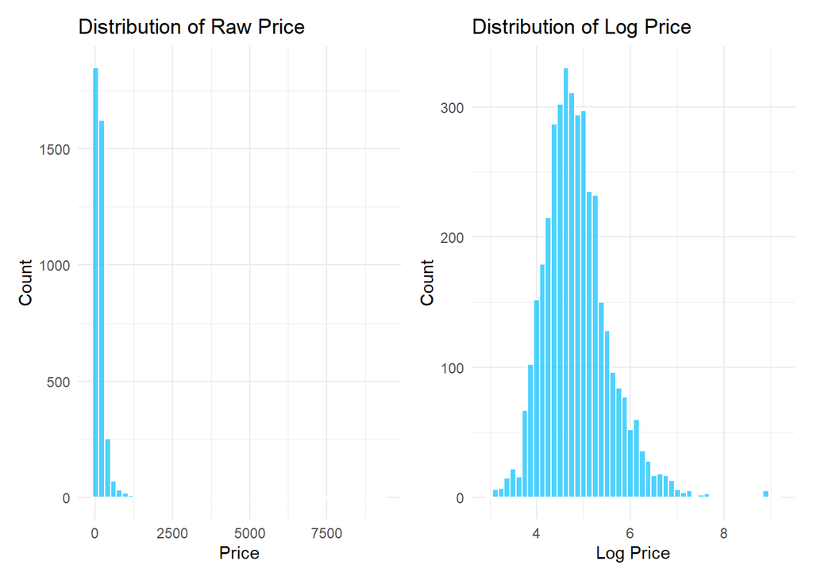

Prices are heavily right-skewed. After log-transformation the distribution is much closer to normal. That is the form we use for the LM, GAM and most diagnostics later.

## 3.2 Capacity & Rating

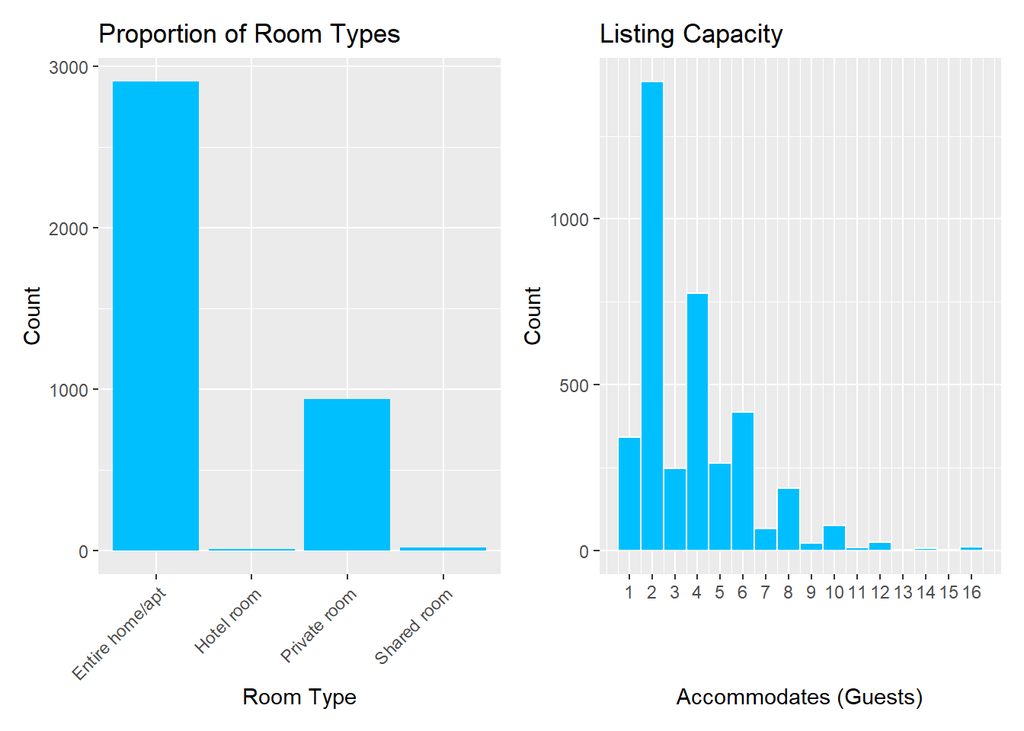

```r
p.room <- ggplot(d.airbnb_listings_feat, aes(x = room_type, fill = room_type)) +
  geom_bar(show.legend = FALSE, fill = "deepskyblue") +
  labs(title = "Proportion of Room Types", x = "Room Type", y = "Count") +
  theme(axis.text.x = element_text(angle = 45, hjust = 1))

p.acc <- ggplot(d.airbnb_listings_feat, aes(x = accommodates)) +
  geom_histogram(binwidth = 1, fill = "deepskyblue", color = "white") +
  scale_x_continuous(breaks = seq(1, max(d.airbnb_listings_feat$accommodates, na.rm = TRUE), by = 1)) +
  labs(title = "Listing Capacity", x = "Accommodates (Guests)", y = "Count")



p.room + p.acc
```

Most listings are built for 2 or 4 guests. Entire homes/apartments and Private rooms dominate the inventory while hotelrooms and shared rooms are marginal.

## 3.3 Room Types & Superhost Status

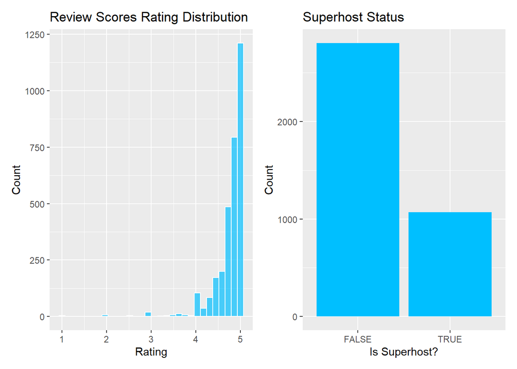

```r
p.rev <- ggplot(d.airbnb_listings_feat, aes(x = review_scores_rating)) +
  geom_histogram(bins = 30, fill = "deepskyblue", color = "white", alpha = 0.7) +
  labs(title = "Review Scores Rating Distribution", x = "Rating", y = "Count")

p.host <- ggplot(d.airbnb_listings_feat %>% filter(!is.na(host_is_superhost)), aes(x = as.factor(host_is_superhost), fill = as.factor(host_is_superhost))) +
  geom_bar(show.legend = FALSE) +
  scale_fill_manual(values = c("deepskyblue", "deepskyblue")) +
  labs(title = "Superhost Status", x = "Is Superhost?", y = "Count")

p.rev + p.host
```

Review scores cluster heavily between 4 and 5. Both hosts and guests rate each other, which probably produces a leniency bias on top of any genuine quality signal. Meanwhile are roughly 30% of hosts Superhosts. This is a meaningful minority, but far from the norm.

## 3.4 Log Prices and rooms / neighbourhoods

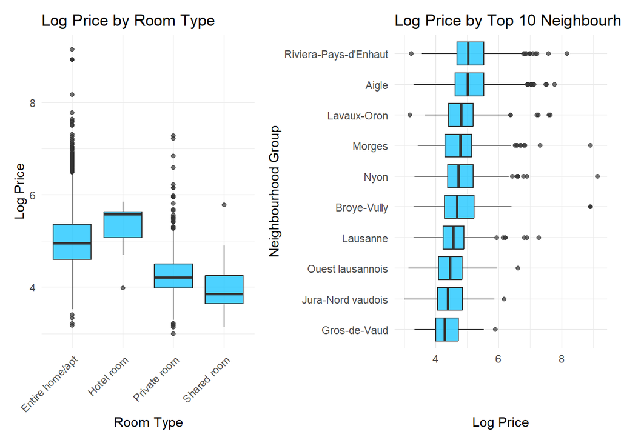

```r
p.logprice_room <- ggplot(d.airbnb_listings_feat, aes(x = room_type, y = log_price, fill = room_type)) +
  geom_boxplot(alpha = 0.7, show.legend = FALSE, fill = "deepskyblue") +
  labs(title = "Log Price by Room Type", x = "Room Type", y = "Log Price") +
  theme(axis.text.x = element_text(angle = 45, hjust = 1))

d.top_neighborhoods <- d.airbnb_listings_feat %>%
  count(neighbourhood_group_cleansed, sort = TRUE) %>%
  top_n(10, n) %>%
  pull(neighbourhood_group_cleansed)

p.logprice_neighbourhood <- ggplot(
  d.airbnb_listings_feat %>% filter(neighbourhood_group_cleansed %in% d.top_neighborhoods),
  aes(x = reorder(neighbourhood_group_cleansed, log_price, FUN = median), y = log_price)
) +
  geom_boxplot(fill = "deepskyblue", alpha = 0.7) +
  coord_flip() +
  labs(
    title = "Log Price by Top 10 Neighbourhood Groups",
    x = "Neighbourhood Group",
    y = "Log Price"
  )

p.logprice_room | p.logprice_neighbourhood
```

Among room types, hotel rooms post the highest median with a tight distribution. Likely a sign of more professional pricing. Entire homes and private rooms show the same shape but a long upper tail (luxury villas, chalets). Shared rooms are the cheapest option as expected. Across neighbourhoods, Riviera-Pays-d’Enhaut and Aigle sit at the top, Gros-de-Vaud at the bottom. Almost all top neighbourhoods show high-end outliers, confirming that luxury listings are spread across the canton, though the baseline price (the “floor”) varies significantly by location.

## 3.5 Host Variables

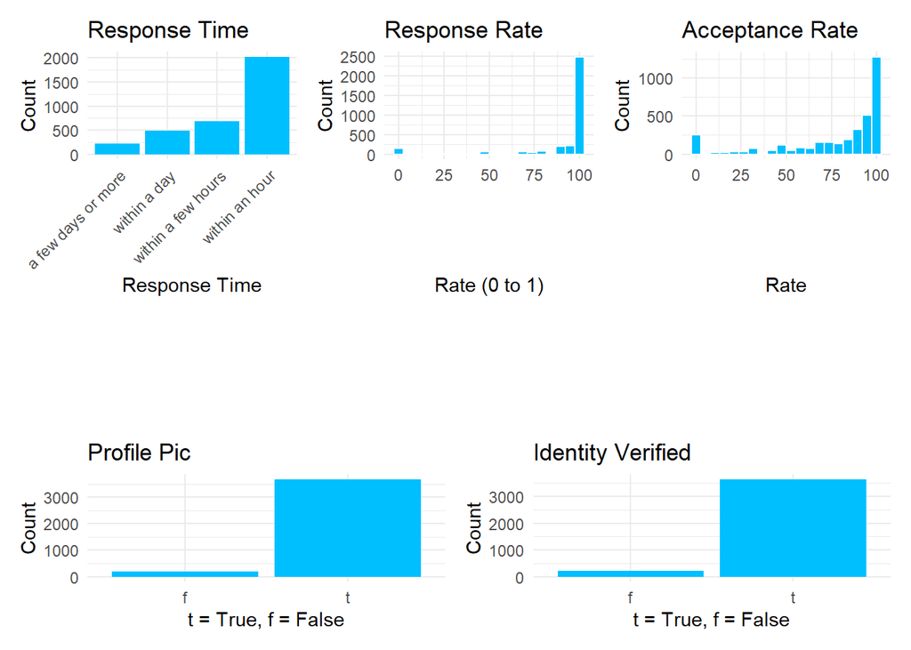

```r
p.resp_time <- ggplot(d.airbnb_listings_feat %>% filter(host_response_time != "N/A" & !is.na(host_response_time)), aes(x = host_response_time)) +
  geom_bar(fill = "deepskyblue") +
  labs(title = "Response Time", x = "Response Time", y = "Count") +
  theme(axis.text.x = element_text(angle = 45, hjust = 1))

p.resp_rate <- ggplot(d.airbnb_listings_feat, aes(x = host_response_rate)) +
  geom_histogram(bins = 20, fill = "deepskyblue", color = "white") +
  labs(title = "Response Rate", x = "Rate (0 to 1)", y = "Count")

p.acc_rate <- ggplot(d.airbnb_listings_feat, aes(x = host_acceptance_rate)) +
  geom_histogram(bins = 20, fill = "deepskyblue", color = "white") +
  labs(title = "Acceptance Rate", x = "Rate", y = "Count")

p.pic <- ggplot(d.airbnb_listings_feat %>% filter(!is.na(host_has_profile_pic)), aes(x = host_has_profile_pic)) +
  geom_bar(fill = "deepskyblue") +
  labs(title = "Profile Pic", x = "t = True, f = False", y = "Count")

p.verified <- ggplot(d.airbnb_listings_feat %>% filter(!is.na(host_identity_verified)), aes(x = host_identity_verified)) +
  geom_bar(fill = "deepskyblue") +
  labs(title = "Identity Verified", x = "t = True, f = False", y = "Count")

(p.resp_time | p.resp_rate | p.acc_rate) /
  plot_spacer() /
  (p.pic | p.verified)
```

Hosts in Vaud are highly responsive and reliable: most reply within an hour, response and acceptance rates add up at 100%, and nearly everyone has a profile picture and verified identity. The downside for modelling: these variables show very little variation, so they probably won’t carry much weight as predictors.

## 3.6 Property Types

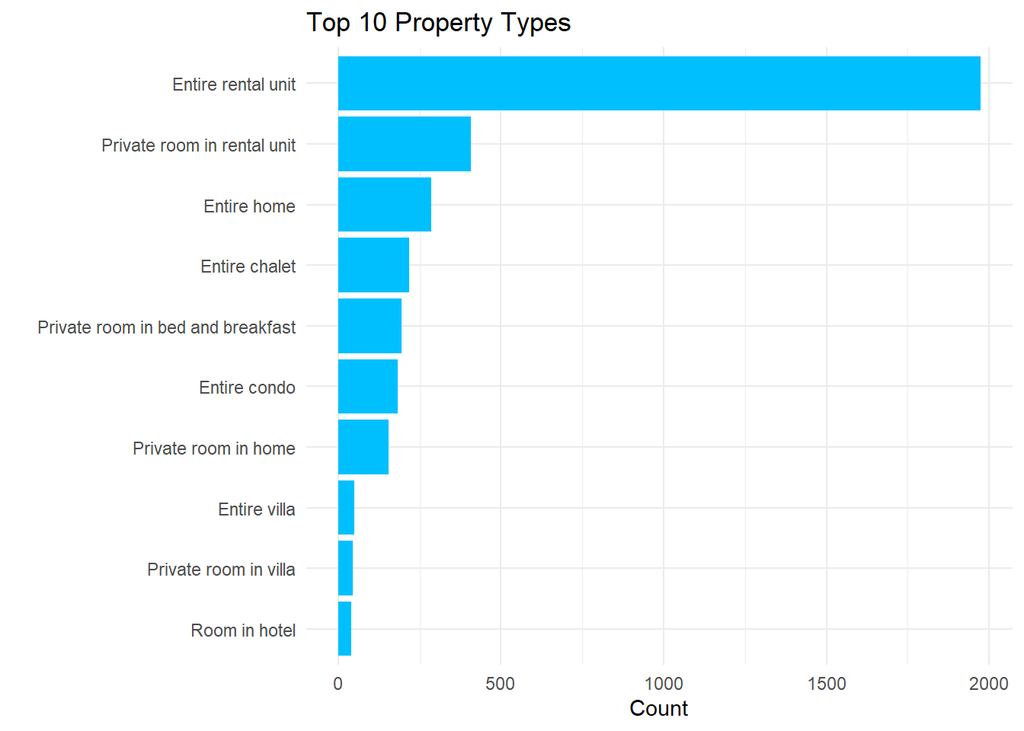

```r
p.prop <- d.airbnb_listings_feat %>%
  count(property_type) %>%
  top_n(10, n) %>%
  ggplot(aes(x = reorder(property_type, n), y = n)) +
  geom_bar(stat = "identity", fill = "deepskyblue") +
  coord_flip() +
  labs(title = "Top 10 Property Types", x = " ", y = "Count")


p.prop
```

## 3.7 Furnishing

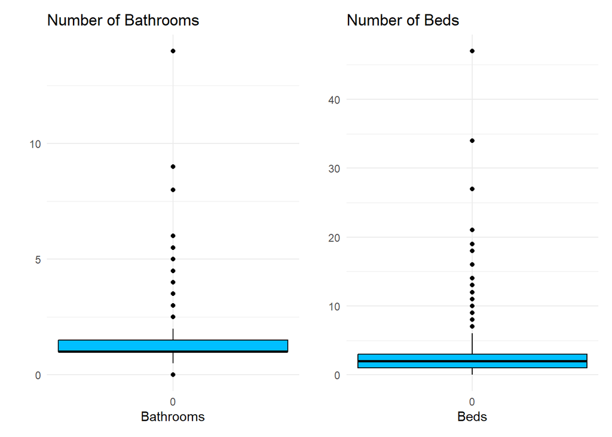

```r
p.baths <- ggplot(d.airbnb_listings_feat, aes(y = bathrooms)) +
  geom_boxplot(fill = "deepskyblue", color = "black") +
  scale_x_continuous(breaks = seq(0, max(d.airbnb_listings_feat$bathrooms, na.rm = TRUE), by = 1)) +
  labs(title = "Number of Bathrooms", x = "Bathrooms", y = " ")

p.beds <- ggplot(d.airbnb_listings_feat, aes(y = beds)) +
  geom_boxplot(fill = "deepskyblue", color = "black") +
  scale_x_continuous(breaks = seq(0, max(d.airbnb_listings_feat$beds, na.rm = TRUE), by = 2)) +
  labs(title = "Number of Beds", x = "Beds", y = " ") +
  theme(axis.ticks.y = element_blank())

p.baths | p.beds
```

Bathroom and bed counts cluster at the low end as expected. The bed distribution has a few extreme outliers (40+ beds), which could be large hostels or dormitories. We checked a few manually but didn’t verify each one, so they remain in the data as potential noise.

## 3.8 Venue Details

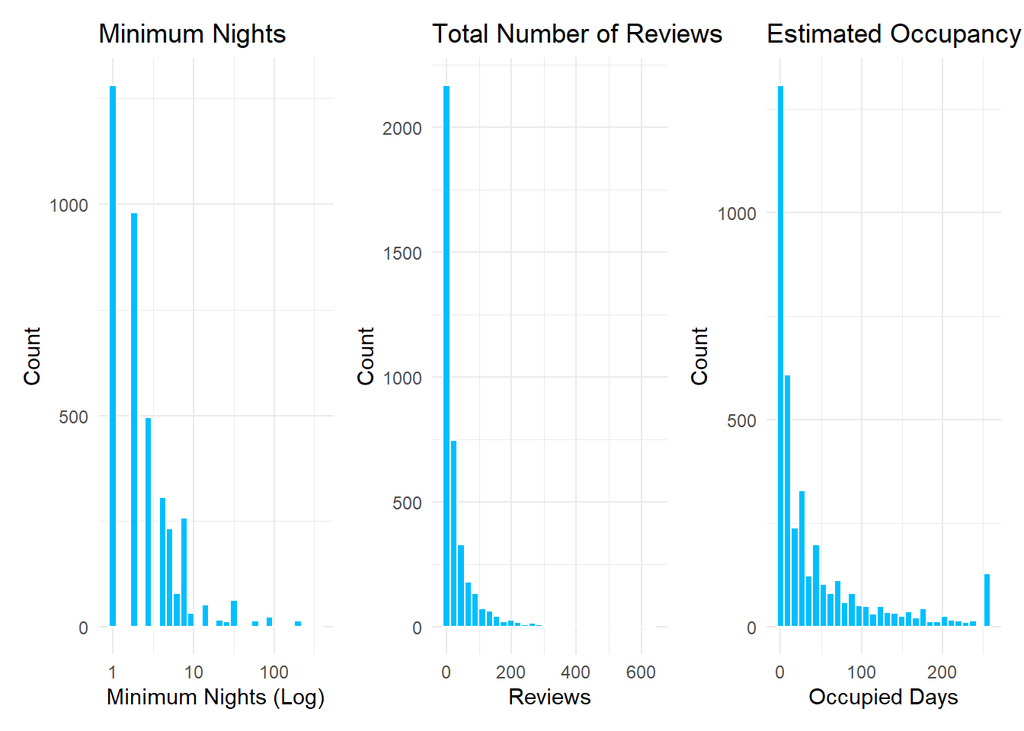

```r
# Minimum Nights (Log scale due to extreme outliers like 365+ nights)
p.nights <- ggplot(d.airbnb_listings_feat, aes(x = minimum_nights)) +
  geom_histogram(bins = 30, fill = "deepskyblue", color = "white") +
  scale_x_log10() +
  labs(title = "Minimum Nights", x = "Minimum Nights (Log)", y = "Count")

p.num_rev <- ggplot(d.airbnb_listings_feat, aes(x = number_of_reviews)) +
  geom_histogram(bins = 30, fill = "deepskyblue", color = "white") +
  labs(title = "Total Number of Reviews", x = "Reviews", y = "Count")

p.occ <- ggplot(d.airbnb_listings_feat, aes(x = estimated_occupancy_l365d)) +
  geom_histogram(bins = 30, fill = "deepskyblue", color = "white") +
  labs(title = "Estimated Occupancy", x = "Occupied Days", y = "Count")

p.nights | p.num_rev | p.occ
```

Minimum nights (log scale) shows a clear preference for short stays with a 1 to 3 nights dominance. A handful of listings enforce 365-day minimums, which is why we plot on a log scale. Review counts are L-shaped: many listings have very few reviews, a small group has hundreds. Estimated occupancy follows the same pattern, with a small spike at the very top end — those are likely commercial operators running close to full capacity year-round.

## 3.9 Feature Engineered Data

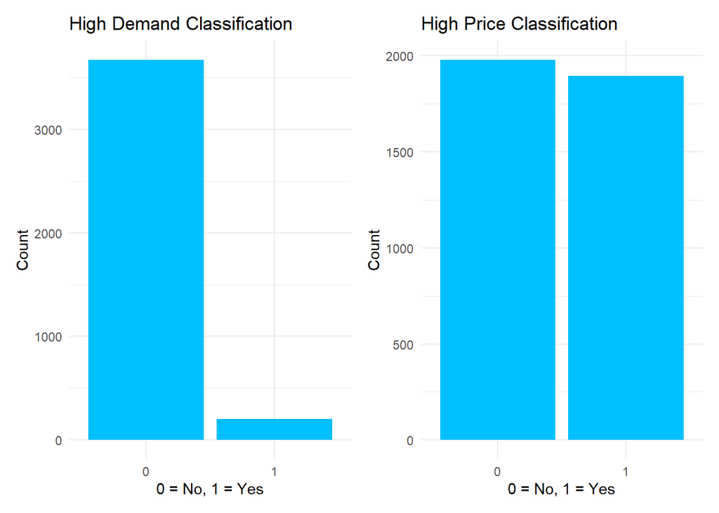

```r
# High Demand (Binary)
p.demand <- ggplot(d.airbnb_listings_feat, aes(x = as.factor(high_demand))) +
  geom_bar(fill = "deepskyblue") +
  labs(title = "High Demand Classification", x = "0 = No, 1 = Yes", y = "Count")

# Price High (Binary)
p.price_high <- ggplot(d.airbnb_listings_feat, aes(x = as.factor(price_high))) +
  geom_bar(fill = "deepskyblue") +
  labs(title = "High Price Classification", x = "0 = No, 1 = Yes", y = "Count")

p.demand | p.price_high
```

High demand is heavily imbalanced: very few listings cross our threshold. Accuracy would be a misleading metric for this target, so for classification on it we’d lean on F1 and precision-recall instead. High price is balanced by design, we split at the median, so both classes have equal weight. The GLM with Family = Binomial uses this target.

## 3.10 Verifications

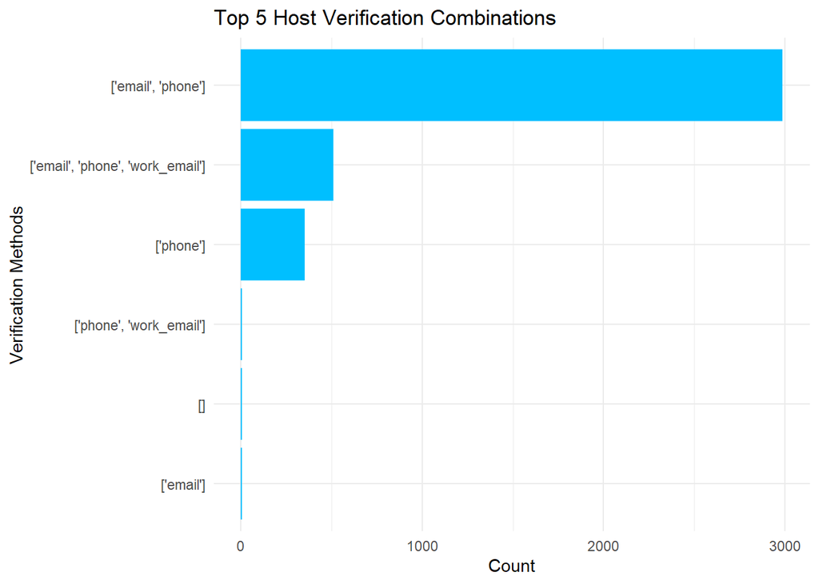

```r
p.verifications <- d.airbnb_listings_feat %>%
  count(host_verifications) %>%
  top_n(5, n) %>%
  ggplot(aes(x = reorder(host_verifications, n), y = n)) +
  geom_bar(stat = "identity", fill = "deepskyblue") +
  coord_flip() +
  labs(title = "Top 5 Host Verification Combinations", x = "Verification Methods", y = "Count")

p.verifications
```

# 4 Data Quality

Using `gg_miss_var()`,we identified that the missing data is not uniformly distributed but concentrated in specific features. The plot below shows where NAs sit. The biggest blocks of missing data are in the rate columns (*response*, *acceptance*) and the *review_scores* variables. For the rates, we considered treating NAs as zero but decided against it, as that would penalise hosts who simply have no reported value rather than a low one. For review scores, the data is most likely missing not at random (MNAR): a listing without reviews is usually a new or unbooked listing rather than a poorly-rated one. Imputing zeros would mislabel these as bad listings, and imputing the mean would artificially shrink variance. We therefore drop these observations from the models that need a rating, rather than imputing.

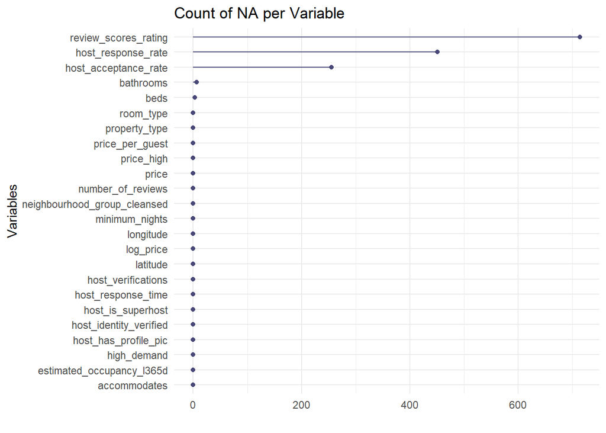

```r
gg_miss_var(d.airbnb_listings_feat) +
  labs(title = "Count of NA per Variable", y = " ")
```

`lm.main` and `svm.main` silently drop rows with missing values, which can quietly shrink the training set. Therefore we have to remember while interpreting those models and using either *review_scores_rating* , *host_response_rate* , *host_acceptance_rate* , *bathrooms* and *beds* that there are NA’s and that they are omitted.

# 5 Exploratory Data Analysis

## 5.1 Overall Market Overview (Prices & Capacity)

This is the absolute minimum, maximum, median, and mean for the most important numeric variables.

```r
# Basic summary statistics for key numerical variables
summary_stats <- d.airbnb_listings_feat %>%
  select(price, accommodates, number_of_reviews) %>%
  summary()


kable(summary_stats, booktabs = TRUE) %>%
  kable_styling()
```

|  | price | accommodates | number_of_reviews |
| --- | --- | --- | --- |
|  | Min. : 20.0 | Min. : 1.000 | Min. : 0.00 |
|  | 1st Qu.: 80.0 | 1st Qu.: 2.000 | 1st Qu.: 1.00 |
|  | Median : 120.0 | Median : 3.000 | Median : 7.00 |
|  | Mean : 178.7 | Mean : 3.755 | Mean : 29.53 |
|  | 3rd Qu.: 185.0 | 3rd Qu.: 5.000 | 3rd Qu.: 32.00 |
|  | Max. :9342.0 | Max. :16.000 | Max. :637.00 |

The mean price sits well above the median, which means a small number of luxury listings is pulling the average upward. The price range stretches over several orders of magnitude. *For any market-level summary we use the median to avoid this skew.*

## 5.2 Analysis by Room Type

Since we want to know how many different types of rooms there are, we group the data and calculate the counts, percentages, and price ranges for each type.

```r
# Detailed breakdown by Room Type
room_type_analysis <- d.airbnb_listings_feat %>%
  group_by(room_type) %>%
  summarise(
    Total_Listings = n(),
    Percentage_of_Market = round((n() / nrow(d.airbnb_listings_feat)) * 100, 1),
    Min_Price = min(price, na.rm = TRUE),
    Median_Price = median(price, na.rm = TRUE),
    Average_Price = round(mean(price, na.rm = TRUE), 1),
    Max_Price = max(price, na.rm = TRUE)
  ) %>%
  arrange(desc(Total_Listings)) # Sorts by the most common room type

kable(room_type_analysis, booktabs = TRUE) %>%
  kable_styling()
```

| room_type | Total_Listings | Percentage_of_Market | Min_Price | Median_Price | Average_Price | Max_Price |
| --- | --- | --- | --- | --- | --- | --- |
| Entire home/apt | 2907 | 75.0 | 24 | 141.0 | 209.8 | 9342 |
| Private room | 940 | 24.3 | 20 | 67.5 | 84.5 | 1450 |
| Shared room | 19 | 0.5 | 23 | 47.0 | 71.9 | 325 |
| Hotel room | 8 | 0.2 | 54 | 264.5 | 223.0 | 349 |

Entire homes and apartments make up roughly three quarters of the market. Hotel rooms have the highest median at 264.5 CHF, shared rooms the lowest at 47 CHF. The same pattern we already saw in the boxplots above.

## 5.3 Detailed property_type Analysis

We already analyzed *room_type*, but Airbnb often has dozens of *property_types* (e.g., *“Entire chalet”*, *“Private room in castle”*…). Summarizing the Top 10 property types in the Canton of Vaud provides us with a great market insight.

```r
top_properties <- d.airbnb_listings_feat %>%
  group_by(property_type) %>%
  summarise(
    Total_Listings = n(),
    Median_Price = median(price, na.rm = TRUE)
  ) %>%
  arrange(desc(Total_Listings)) %>%
  slice_head(n = 10) # Keep only the top 10

kable(top_properties, caption = "Top 10 Property Types in the Canton of Vaud", booktabs = TRUE) %>%
  kable_styling()
```

Top 10 Property Types in the Canton of Vaud

| property_type | Total_Listings | Median_Price |
| --- | --- | --- |
| Entire rental unit | 1973 | 128.0 |
| Private room in rental unit | 409 | 64.0 |
| Entire home | 287 | 250.0 |
| Entire chalet | 219 | 250.0 |
| Private room in bed and breakfast | 194 | 69.5 |
| Entire condo | 184 | 136.5 |
| Private room in home | 154 | 66.0 |
| Entire villa | 50 | 370.0 |
| Private room in villa | 45 | 68.0 |
| Room in hotel | 40 | 177.0 |

Standard rental units dominate, but specialty properties like chalets, villas, homes command a noticeable premium. The LM and GAM both include *room_type* for exactly this reason.

## 5.4 Correlation Matrix

Before we train our LM, GAM, or SVM, we need to know how our numerical variables relate to each other. This helps us identify multicollinearity (when two predictors provide the same information) and strong price drivers.

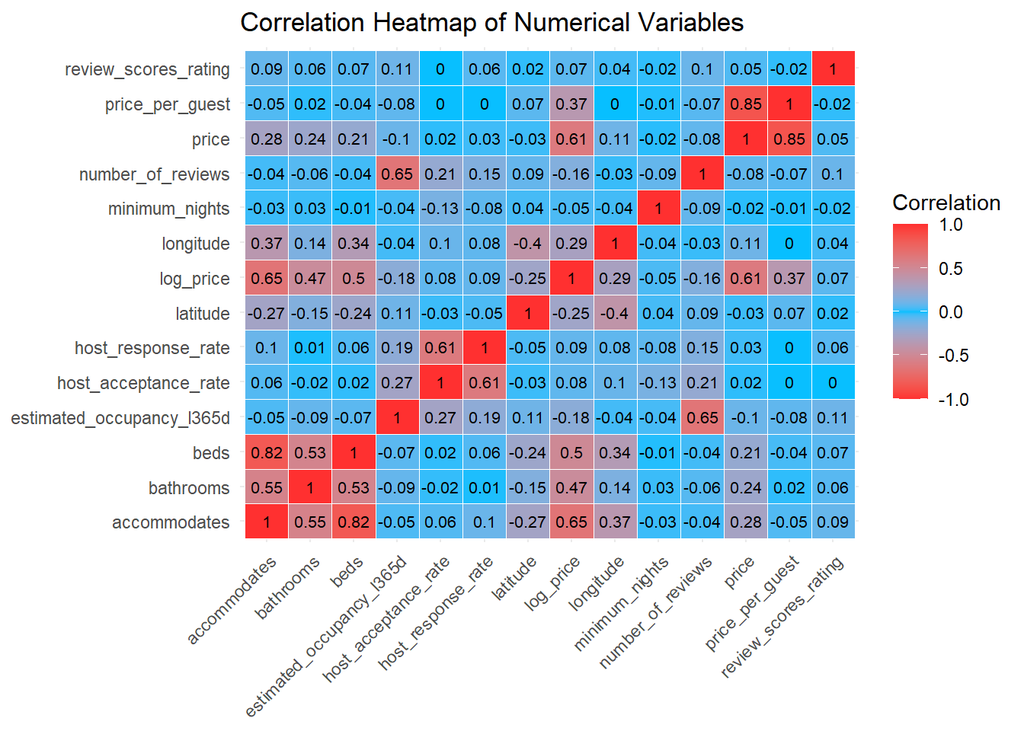

```r
# Select all numerical variables, drop binaries we already analysed separately
num_vars <- d.airbnb_listings_feat %>%
  select(where(is.numeric)) %>%
  select(-price_high, -high_demand)

# Correlation matrix with pairwise complete observations to handle NAs
cor_matrix_full <- cor(num_vars, use = "pairwise.complete.obs")

# Reshape for ggplot
cor_long <- as.data.frame(cor_matrix_full) %>%
  rownames_to_column("Var1") %>%
  pivot_longer(-Var1, names_to = "Var2", values_to = "Correlation")

ggplot(cor_long, aes(x = Var1, y = Var2, fill = Correlation)) +
  geom_tile(color = "white") +
  geom_text(aes(label = round(Correlation, 2)), size = 2.8) +
  scale_fill_gradient2(
    low = "firebrick1", mid = "deepskyblue", high = "firebrick1",
    midpoint = 0, limits = c(-1, 1)
  ) +
  labs(
    title = "Correlation Heatmap of Numerical Variables",
    x = NULL, y = NULL
  ) +
  theme(axis.text.x = element_text(angle = 45, hjust = 1))
```

## 5.5 Log Price vs. Accommodates

This is the most important relationship in the dataset from what we see in the correlation matrix above.

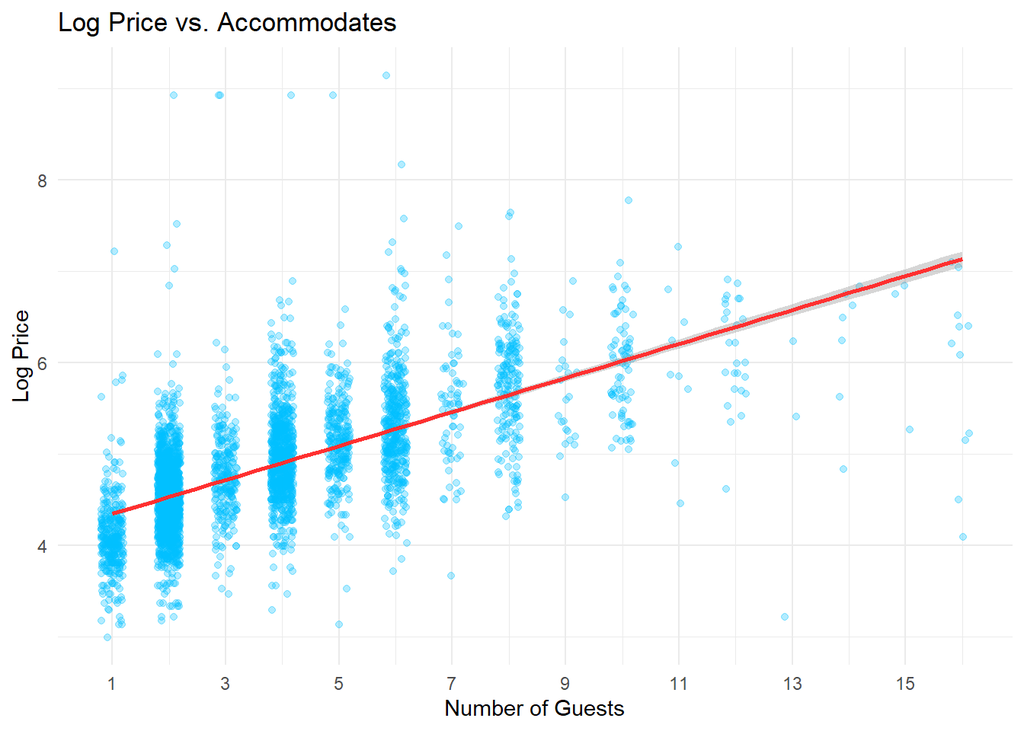

```r
ggplot(d.airbnb_listings_feat, aes(x = accommodates, y = log_price)) +
  geom_jitter(alpha = 0.3, width = 0.2, color = "deepskyblue") +
  geom_smooth(method = "lm", color = "firebrick1", se = TRUE) +
  scale_x_continuous(breaks = seq(1, max(d.airbnb_listings_feat$accommodates, na.rm = TRUE), 2)) +
  labs(
    title = "Log Price vs. Accommodates",
    x = "Number of Guests",
    y = "Log Price"
  )
```

**Capacity is the strongest single predictor in the dataset**, and the relationship looks roughly linear on the log scale, which is exactly why we work with `log_price` throughout the LM and GAM.

## 5.6 Log Price by Review Score Group

We already looked at *review_scores_rating* on its own, but never in relation to the price.

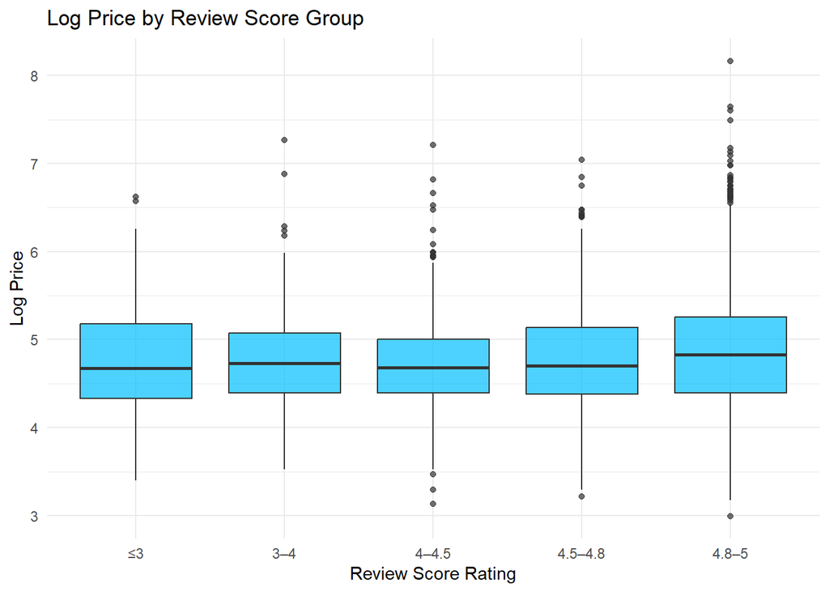

```r
d.airbnb_listings_feat %>%
  filter(!is.na(review_scores_rating)) %>%
  mutate(rating_group = cut(review_scores_rating,
    breaks = c(0, 3, 4, 4.5, 4.8, 5),
    labels = c("≤3", "3–4", "4–4.5", "4.5–4.8", "4.8–5"),
    include.lowest = TRUE
  )) %>%
  ggplot(aes(x = rating_group, y = log_price, fill = rating_group)) +
  geom_boxplot(alpha = 0.7, show.legend = FALSE, fill = "deepskyblue") +
  labs(
    title = "Log Price by Review Score Group",
    x = "Review Score Rating",
    y = "Log Price"
  )
```

Medians across rating groups are surprisingly close. Higher-rated listings do not automatically charge more. A first hint at the Superhost pattern we’ll come back to: in this market, reputation correlates with occupancy strategies more than with price premiums.

## 5.7 Spatial Data: Mapping the Listings by Log(Price)

[figure not shown]

```r
# Cleaned up the map to focus purely on location and price.
ggplot(data = d.airbnb_listings_feat, aes(x = longitude, y = latitude)) +
  geom_point(aes(color = log_price), alpha = 0.6, size = 1.5) +
  scale_color_continuous(palette = c("deepskyblue", "firebrick1", "gold")) +
  labs(
    title = "Airbnb Listings in Vaud by Log(Price)",
    x = "Longitude",
    y = "Latitude",
    color = "log_price"
  ) +
  theme_minimal()
```

Hotspots cluster along Lake Geneva and around Lausanne, with rural and alpine areas trailing off. This is exactly the surface the GAM picks up later with its 2D spline and the reason we use raw coordinates rather than a postcode dummy.

## 5.8 Price per Guest Distribution

We calculated price per guest as a feature then visualized them.

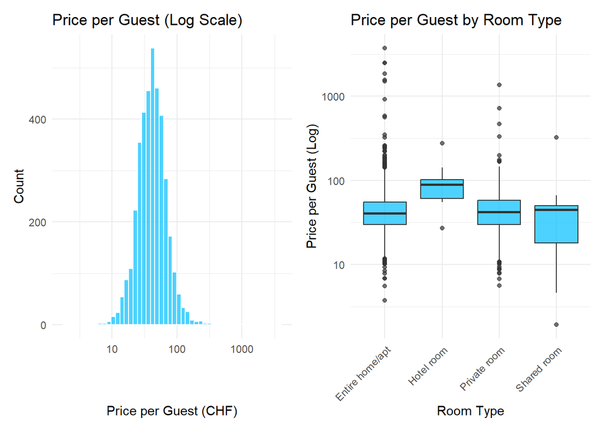

```r
p_ppg <- ggplot(d.airbnb_listings_feat, aes(x = price_per_guest)) +
  geom_histogram(bins = 50, fill = "deepskyblue", color = "white", alpha = 0.7) +
  scale_x_log10() +
  labs(
    title = "Price per Guest (Log Scale)",
    x = "Price per Guest (CHF)", y = "Count"
  )

p_ppg_room <- ggplot(d.airbnb_listings_feat, aes(x = room_type, y = price_per_guest, fill = room_type)) +
  geom_boxplot(alpha = 0.7, show.legend = FALSE, fill = "deepskyblue") +
  scale_y_log10() +
  labs(
    title = "Price per Guest by Room Type",
    x = "Room Type", y = "Price per Guest (Log)"
  ) +
  theme(axis.text.x = element_text(angle = 45, hjust = 1))

p_ppg + p_ppg_room
```

## 5.9 Superhost vs. Regular Host Breakdown

This business case specifically mentions superhost status. So we took a look to see how many there are and if they actually charge more or even less.

```r
# Superhost statistics
superhost_analysis <- d.airbnb_listings_feat %>%
  group_by(host_is_superhost) %>%
  summarise(
    Total_Hosts = n(),
    Percentage = round((n() / nrow(d.airbnb_listings_feat)) * 100, 1),
    Median_Price = median(price, na.rm = TRUE),
    Avg_Reviews = round(mean(number_of_reviews, na.rm = TRUE), 1)
  ) %>%
  mutate(host_is_superhost = ifelse(host_is_superhost == 1, "Yes", "No"))

kable(superhost_analysis, booktabs = TRUE) %>%
  kable_styling()
```

| host_is_superhost | Total_Hosts | Percentage | Median_Price | Avg_Reviews |
| --- | --- | --- | --- | --- |
| No | 2805 | 72.4 | 122 | 17.3 |
| Yes | 1069 | 27.6 | 112 | 61.6 |

At first glance the boxplot shows almost no difference in median price between Superhosts and regular hosts. This is our first sign that the Superhost badge does not translate into a price premium; a pattern that the GLM Binomial, the GAM and the Neural Network will all confirm independently in the next chapters.

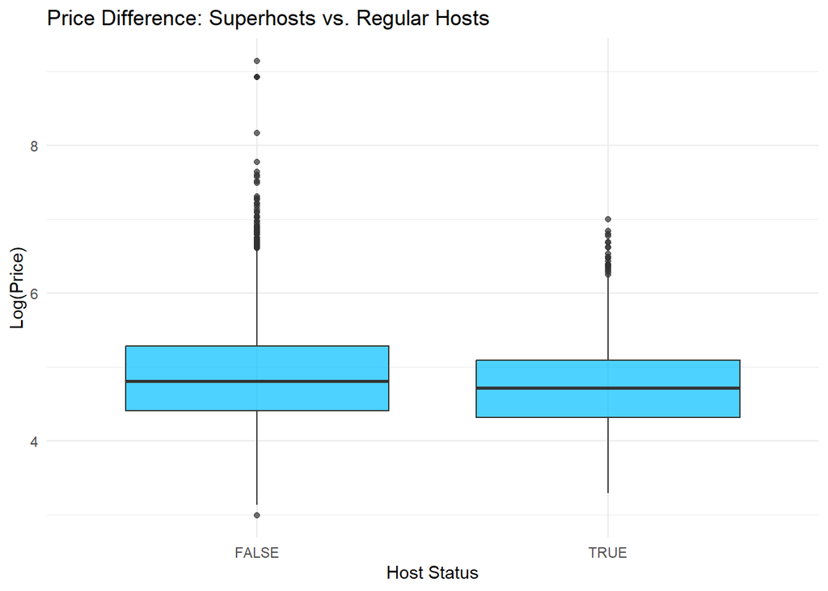

```r
# Adding this because it's a key part of the business case and fulfills the binary variable requirement.
ggplot(data = d.airbnb_listings_feat, aes(x = as.factor(host_is_superhost), y = log_price, fill = as.factor(host_is_superhost))) +
  geom_boxplot(alpha = 0.7, fill = "deepskyblue") +
  scale_x_discrete(labels = c("0" = "Regular Host", "1" = "Superhost")) +
  labs(
    title = "Price Difference: Superhosts vs. Regular Hosts",
    x = "Host Status",
    y = "Log(Price)"
  ) +
  theme_minimal() +
  theme(legend.position = "none")
```

# 6 Modelling Approach

We build six models, each looking at price, occupancy from a different angle. The point isn’t to pick one winner. It’s to triangulate. When models with very different mechanics converge on the same answer, we can trust it more than any single result. To achieve this, we assigned every model a hypothesis to make sure that ever Hypothesis has a Model that matches the requirements of the model.

| Model | Question | Hypothesis | Output |
| --- | --- | --- | --- |
| Linear Model | Which variables shift price linearly? | H1 | Coefficients |
| GLM Poisson | Which variables drive occupancy? | H1 + H2 | Rate ratios |
| GLM Binomial | Who ends up in the upper price half? | H1 | Odds ratios |
| GAM | What does the non-linear price surface look like? | H2 (with H1 as control) | Smooth curves + fair price per listing |
| SVM | Is a given listing under-, fair-, or overpriced? | RQ2 (prediction) | Classification verdict |
| ANN | Does any host effect survive flexible controls? | H1 | Predicted prices for hypothetical hosts |

The LM is our baseline. Anything more complex needs to clearly beat it. The GLM Poisson runs the same question on a different target (occupancy instead of price), which lets us spot situations where a variable affects one but not the other. The GLM Binomial reduces the price question to a yes/no decision (above or below median), which makes the host effect cleaner to read.

The GAM captures the non-linear effects we already saw in the EDA and adds a 2D spatial term that no other model has. The SVM then operationalises the GAM into a working tool, given a listing and a chosen price, it returns Underpriced, Fair, or Overpriced.

The ANN doesn’t add new information so much as it checks our assumptions. If a flexible neural network barely beats the GAM, the GAM is already capturing most of the available signal and we can trust the interpretable model over the black box.

The GAM, SVM and ANN are evaluated on held-out test data. The split is made once on the cleaned dataset, before any model fits and reused throughout. This matters especially for the SVM: its training labels come from the GAM’s fair-price band, so if we split after labelling, GAM information would leak into the SVM’s test set. We split first, fit the GAM only on the training set, then derive labels.

# 7 Linear Model

## 7.1 Theory

With this initial model, we aim to examine the first hypothesis if host-centered indicators shift price?

For this, we use the *review_scores_rating*. We also include the factor *host_is_superhost* to distinguish between the two groups. We measure willingness to pay here using the *price* of the rental property. Additionally, we introduce two control variables to the Model. First, the size of the rental property with the help of *accommodates*, as this obviously influences the rental price, and second, *room_type*. The latter we include since we can assume that a hotel room has different services than a room of a private lessor and that the venues need to priced differently.

A linear model allows us to analyze multiple variables and their effect on a dependent variable. It is important that the dependent variable be normally distributed. Since this is not the case here, as is often the case with price variables, this variable is logarithmized.

## 7.2 Model

In this Chapter, we will calculate a linear model to be able to give an answer to the first Hypothesis.

```r
# We use log(price) to account for the right-skewed distribution of Airbnb prices.
lm.main <- lm(
  log_price ~
    review_scores_rating +
    as.factor(host_is_superhost) +
    host_has_profile_pic +
    accommodates +
    as.factor(room_type),
  data = d.airbnb_listings_feat
)

tidy(lm.main) %>%
  kable(digits = 2, booktabs = TRUE, caption = "SVM Model Overview") %>%
  kable_styling()
```

| term | estimate | std.error | statistic | p.value |
| --- | --- | --- | --- | --- |
| (Intercept) | 4.02 | 0.11 | 36.94 | 0.00 |
| review_scores_rating | 0.07 | 0.02 | 3.33 | 0.00 |
| as.factor(host_is_superhost)TRUE | -0.11 | 0.02 | -6.64 | 0.00 |
| host_has_profile_pict | 0.04 | 0.04 | 1.00 | 0.32 |
| accommodates | 0.15 | 0.00 | 41.23 | 0.00 |
| as.factor(room_type)Hotel room | 0.56 | 0.15 | 3.61 | 0.00 |
| as.factor(room_type)Private room | -0.41 | 0.02 | -20.03 | 0.00 |
| as.factor(room_type)Shared room | -0.82 | 0.11 | -7.44 | 0.00 |

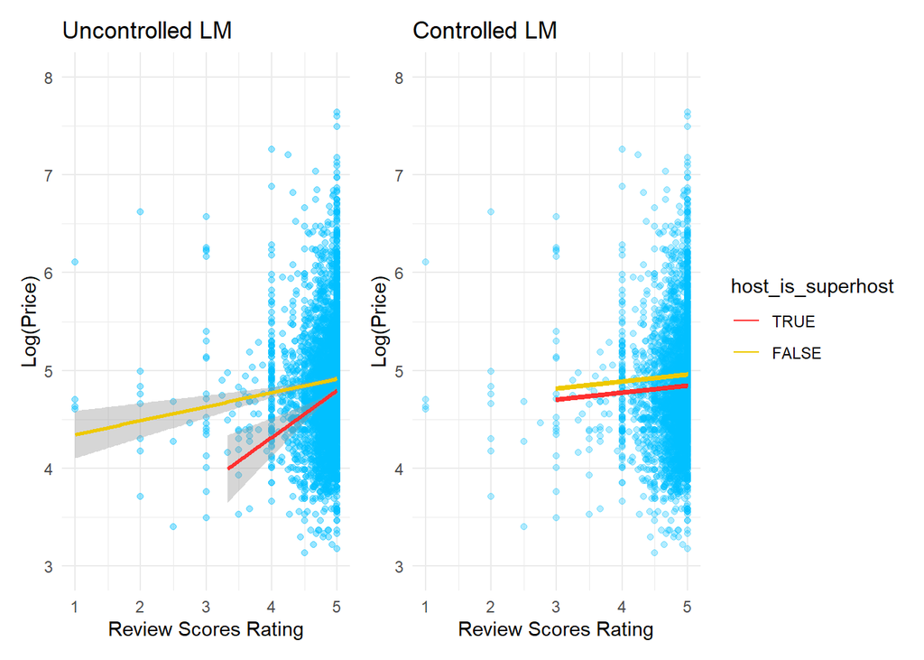

```r
# plot log-price and scores + superhost
p.lm_uncontrolled <- ggplot(data = d.airbnb_listings_feat, mapping = aes(review_scores_rating, log_price, color = host_is_superhost), ylim = 8) +
  geom_point(alpha = 0.4, color = "deepskyblue") +
  geom_smooth(method = "lm") +
  scale_color_manual(values = c("FALSE" = "gold2", "TRUE" = "firebrick1")) +
  labs(
    title = "Uncontrolled LM",
    x = "Review Scores Rating",
    y = "Log(Price)"
  ) +
  theme(legend.position = "none") +
  ylim(3, 8)

# creating grid for hypothetical data holding 'room_type' and 'accommodates' constant
d.lm_predict <- expand.grid(
  review_scores_rating = seq(3, 5, length.out = 100),
  host_is_superhost = c("TRUE", "FALSE"),
  room_type = "Entire home/apt", # Fixed reference category
  host_has_profile_pic = c("t", "f"),
  accommodates = mean(d.airbnb_listings_feat$accommodates, na.rm = TRUE) # Fixed at mean value
)

# Generating predictions
d.lm_predict$pred <- predict(lm.main, newdata = d.lm_predict)

# Plotting the actual data points alongside our model's predicted regression lines
p.lm_controlled <- ggplot(
  d.airbnb_listings_feat,
  aes(review_scores_rating, log_price, color = host_is_superhost, )
) +
  geom_point(alpha = 0.3, color = "deepskyblue") +
  geom_line(data = d.lm_predict, aes(y = pred)) +
  scale_color_manual(values = c("FALSE" = "gold2", "TRUE" = "firebrick1")) +
  labs(
    title = "Controlled LM",
    x = "Review Scores Rating",
    y = "Log(Price)"
  ) +
  ylim(3, 8)

(p.lm_uncontrolled | p.lm_controlled) +
  plot_layout(widths = c(10, 10))
```

## 7.3 Interpretation

The model shows that both the hosts’ rating and their superhost status have a significant influence. The *review_scores_rating* has a positive effect of *0.071*. In contrast, *is_superhost* status has a negative effect of *-0.114*. With the interpretation of these Values we have to be careful, since there is a logarithm involved. For every increase of a rating by 1, the price rises about 7.41%. If a host becomes a superhost, his prices are reduced by 10.75%.

The idea that tenants are willing to pay more when renting from a Superhost therefore does not necessarily seem to hold true. One possible explanation for this phenomenon is that Superhosts may have a better understanding of the market because they have been active for a longer time, and therefore set lower prices in order to achieve a higher occupancy rate. This is relevant for Airbnb, as these results show that reviews on the host side are a key factor in price setting. It is also interesting that Superhosts might develop their own understanding for how prices can be set. The exact reasons underlying this difference cannot be examined within the scope of this paper. Through this analysis we can also answer the first hypothesis. Host centered Variables, in this case the *review_scores_rating* and *host_is_superhost*, do change the price of a venue.

## 7.4 Limitations

A linear model often comes with certain limitations, as the degree of complexity is limited. We can only observe linear effects. We can assume that capacity is not a linear effect, since the price of a location can vary depending on whether it accommodates 3 or 4 people, whereas the effect of one fewer person is less significant if the location accommodates 15 or 16 people. A GAM model could reveal such effects. Another limitation is the absence of a “location” variable. While we could include latitude and longitude, these variables alone do not have a significant impact on price. For example, we would need the distance to the nearest city center to measure this accurately.

*General limitations that apply to every model in this study are summarised in chapter 14.*

# 8 Generalized linear Model — Poisson

## 8.1 Theory

With the GLM model with Poisson-family / quasi-poisson family is used to analyse count data. Count data is strictly positive and counted (not continuous). Using this model we want to see which variables lead to the highest occupancy, meaning most of the time the airbnb is rented out. As the data is probably overdispersed, meaning the data has not the same variance and much more cheap listings than expensive ones, we need to use a quasi-poisson model that can handle this kind of data much better. First we fit a normal poisson-family, then check for overdispersion, and if necessary we use a quasi-poisson-family.

This is the only model in our set that targets occupancy rather than price. Both hypotheses are in scope, host-centered indicators (H1) and structural indicators (H2) can both drive how often a listing gets booked. The answer turns out to be the missing piece of the Superhost puzzle the other models will and have surfaced.

## 8.2 Model

In this subchapter we code Generalized Linear Models. One using Poisson-Distribution, then we check vor Overdispersion, and if necessary we use a Generalized Linear Model using Quasi-Poisson-Distribution.

```r
glm.poisson <- glm(
  estimated_occupancy_l365d ~ price + host_is_superhost +
    review_scores_rating + accommodates + room_type,
  data = d.airbnb_listings_feat,
  family = "poisson"
)
# Dispersion check
dispersion_ratio <- glm.poisson$deviance / glm.poisson$df.residual

glm.quasipoisson <- glm(
  estimated_occupancy_l365d ~ price + host_is_superhost +
    review_scores_rating + accommodates + room_type,
  data = d.airbnb_listings_feat,
  family = "quasipoisson"
)

tidy.poisson <- tidy(glm.poisson) %>% mutate(Model = "Poisson")
tidy.quasi <- tidy(glm.quasipoisson) %>% mutate(Model = "Quasi-Poisson")

combined_models <- bind_rows(tidy.poisson, tidy.quasi) %>%
  select(term, estimate, std.error, statistic, p.value)

combined_models %>%
  kable(
    digits = 3,
    booktabs = TRUE,
    caption = paste0("Comparing Models (Dispersion Ratio: ", round(dispersion_ratio, 2), ")")
  ) %>%
  kable_styling(font_size = 8, latex_options = c("scale_down", "hold_position")) %>%
  collapse_rows(columns = 1, valign = "top") %>%
  group_rows("GLM poisson", 1, 8) %>%
  group_rows("GLM quasi-poisson", 9, 16)
```

Comparing Models (Dispersion Ratio: 56.53)

| term | estimate | std.error | statistic | p.value |
| --- | --- | --- | --- | --- |
| **GLM poisson** |  |  |  |  |
| (Intercept) | 2.803 | 0.043 | 64.817 | 0.000 |
| price | -0.003 | 0.000 | -81.858 | 0.000 |
| host_is_superhostTRUE | 0.957 | 0.005 | 189.086 | 0.000 |
| review_scores_rating | 0.226 | 0.009 | 24.766 | 0.000 |
| accommodates | 0.038 | 0.001 | 26.763 | 0.000 |
| room_typeHotel room | 0.553 | 0.038 | 14.504 | 0.000 |
| room_typePrivate room | -0.136 | 0.006 | -21.649 | 0.000 |
| room_typeShared room | -0.188 | 0.035 | -5.338 | 0.000 |
| **GLM quasi-poisson** |  |  |  |  |
| (Intercept) | 2.803 | 0.367 | 7.642 | 0.000 |
| price | -0.003 | 0.000 | -9.652 | 0.000 |
| host_is_superhostTRUE | 0.957 | 0.043 | 22.294 | 0.000 |
| review_scores_rating | 0.226 | 0.078 | 2.920 | 0.004 |
| accommodates | 0.038 | 0.012 | 3.156 | 0.002 |
| room_typeHotel room | 0.553 | 0.323 | 1.710 | 0.087 |
| room_typePrivate room | -0.136 | 0.053 | -2.553 | 0.011 |
| room_typeShared room | -0.188 | 0.299 | -0.629 | 0.529 |

## 8.3 Interpretations

### 8.3.1 Interpretation GLM-Poisson

As expected, the GLM with a Poisson distribution produced overdispersion, since the variability in the Airbnb data was to be expected. The model calculated the standard errors too small, which is why all variables were highly significant in the first output. The dispersion was then calculated and found to be greater than 1, specifically 56.53. A quasi-Poisson model was used as a solution, which adjusts the standard errors upward.

### 8.3.2 Interpretation GLM-Quasipoisson

By utilizing a quasi-Poisson model, we successfully corrected for overdispersion in the data. This adjustment provides more realistic standard errors, ensuring a highly reliable evaluation of the actual drivers behind property occupancy.

Our analysis identifies several key factors influencing performance. **Price** has a highly significant negative impact; as expected, higher rates consistently lead to lower occupancy. Conversely, achieving **Superhost status** is a major advantage. It exerts a highly significant positive effect, multiplying a property’s occupancy by approximately **2.6 times** compared to standard hosts. Additionally, both **guest reviews** and **property capacity** are strong, significant drivers of success which means that better ratings and the ability to accommodate more guests reliably translate into higher booking volumes.

Finally, the **room type** plays a crucial role. When comparing setups against the baseline of renting an *Entire home/apt* **private rooms** experience significantly lower occupancy rates. However, for **shared rooms**, the data does not reveal a statistically significant difference in occupancy compared to booking an entire apartment.

### 8.3.3 Cross-validation

To ensure that the higher number of variables does not cause overfitting, we use cross-validation. In this process, we repeatedly split the data into new subsets, which we use to retrain and re-evaluate the model. We then check to see if there are any significant fluctuations. If the model were overfitting, we would repeatedly observe random fluctuations and therefore outliers in the plot.

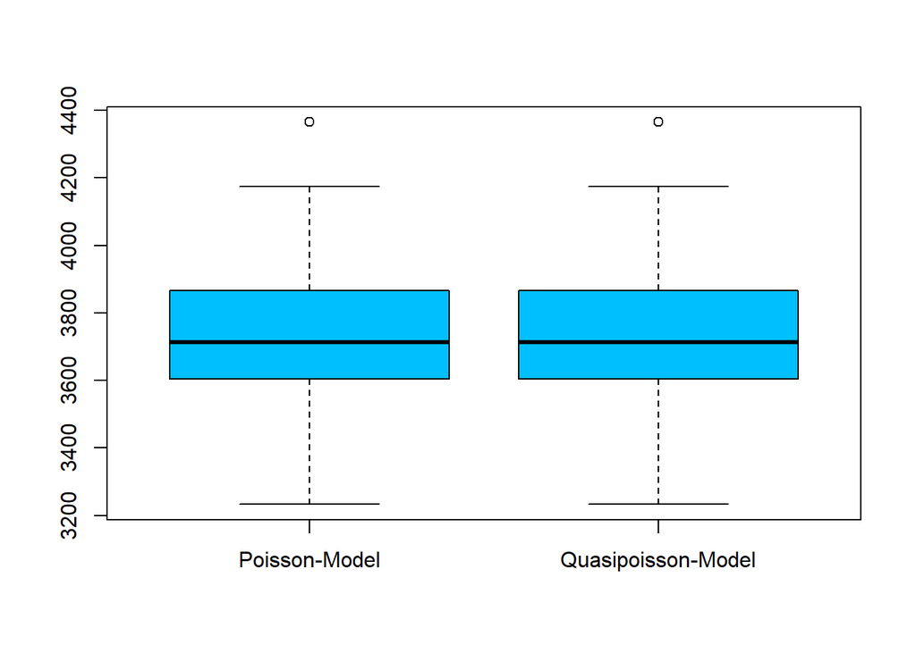

```r
set.seed(1)

cv.mse.poisson <- c()
cv.mse.quasipoisson <- c()

for (i in 1:200) {
  # dataprep
  n <- nrow(d.airbnb_listings_feat)
  cv.ind_permuted <- sample(1:n, replace = FALSE)
  d.airbnb_listings_feat_permuted <- d.airbnb_listings_feat[cv.ind_permuted, ]

  # create folds
  cv.folds <- cut(1:n, breaks = 3, labels = FALSE)
  cv.ind_test <- which(cv.folds == 1)

  d.cv_test <- d.airbnb_listings_feat_permuted[cv.ind_test, ]
  d.cv_train <- d.airbnb_listings_feat_permuted[-cv.ind_test, ]

  # train model poisson
  cv.glm_poisson_train <- glm(
    formula = formula(glm.poisson),
    data = d.cv_train
  )
  cv.glm_poisson_predict <- predict(cv.glm_poisson_train, newdata = d.cv_test)

  cv.mse.poisson[i] <- mean((d.cv_test$estimated_occupancy_l365d - cv.glm_poisson_predict)^2,
    na.rm = TRUE
  )


  # train model quasipoisson
  cv.glm_quasipoisson_train <- glm(
    formula = formula(glm.quasipoisson),
    data = d.cv_train
  )
  cv.glm_quasipoisson_predict <- predict(cv.glm_quasipoisson_train, newdata = d.cv_test)

  cv.mse.quasipoisson[i] <- mean((d.cv_test$estimated_occupancy_l365d - cv.glm_quasipoisson_predict)^2,
    na.rm = TRUE
  )
}

boxplot(cv.mse.poisson, cv.mse.quasipoisson, names = c("Poisson-Model", "Quasipoisson-Model"), col = "deepskyblue")
```

In our case, however, we only get a single outlier, which suggests that we have a stable model without overfitting.

## 8.4 Limitations

A primary limitation of this model is the potential for reverse causality, as higher occupancy naturally generates more reviews, making it easier to maintain high ratings and Superhost status. Additionally, the deletion of 714 observations due to missingness (na.omit) could introduce survivorship bias if these removed data points represent poorly managed or unsuccessful listings. Furthermore, our feature set omits critical demand drivers like precise neighborhood desirability, seasonality, and listing photo quality, meaning unobserved factors likely account for significant residual variance. A potential next step could be exploring a Negative Binomial model as an alternative method to handle overdispersion while retaining standard likelihood metrics for easier comparison.

# 9 Generalized linear model — Binomial

## 9.1 Theory

When the outcome we want to model is binary, yes/no, above/below, a standard linear regression no longer fits. A Binomial GLM with a logit link is the natural choice: it bounds predictions between 0 and 1 and returns coefficients we can read as log-odds. Exponentiating gives odds ratios, which are easier to communicate to a non-technical audience. Our binary target *price_high* equals 1 if a listing’s price is above the median and 0 otherwise. The median split gives us two equally sized classes, so the model is not biased toward a majority outcome.

This model speaks mainly to H1: do host-centered indicators (Superhost status, ratings) push up the price? The control variables (*accommodates*, *room_type*) are not the focus but we make sure we don’t confuse host effects with listing characteristics.

## 9.2 Model

```r
# Predict the probability that a listing is priced above the market median
# We control for the most obvious price drivers so the host coefficients can be read cleanly
glm.binomial <- glm(
  price_high ~ host_is_superhost +
    accommodates +
    room_type +
    review_scores_rating,
  data = d.airbnb_listings_feat,
  family = binomial(link = "logit")
)


# Convert log-odds into odds ratios with 95% confidence intervals for easier reading
d.results_glm_binomial <- tidy(glm.binomial, conf.int = TRUE) %>%
  mutate(
    odds_ratio = round(exp(estimate), 3),
    or_lower   = round(exp(conf.low), 3),
    or_upper   = round(exp(conf.high), 3),
    p.value    = round(p.value, 4)
  ) %>%
  select(term, estimate, odds_ratio, or_lower, or_upper, p.value)

kable(d.results_glm_binomial,
  caption = "GLM Binomial: Odds Ratios with 95% Confidence Intervals"
) %>%
  kable_styling()
```

GLM Binomial: Odds Ratios with 95% Confidence Intervals

| term | estimate | odds_ratio | or_lower | or_upper | p.value |
| --- | --- | --- | --- | --- | --- |
| (Intercept) | -4.1629586 | 0.016 | 0.004 | 0.051 | 0.0000 |
| host_is_superhostTRUE | -0.3668731 | 0.693 | 0.570 | 0.841 | 0.0002 |
| accommodates | 0.6063184 | 1.834 | 1.732 | 1.945 | 0.0000 |
| room_typeHotel room | 1.7511366 | 5.761 | 1.259 | 40.642 | 0.0372 |
| room_typePrivate room | -1.5380852 | 0.215 | 0.162 | 0.281 | 0.0000 |
| room_typeShared room | -3.4821194 | 0.031 | 0.002 | 0.334 | 0.0177 |
| review_scores_rating | 0.4831448 | 1.621 | 1.262 | 2.109 | 0.0002 |

## 9.3 Visualisation

A coefficient table is hard to read for hosts. The plot below shows the predicted probability of charging an above-median price across listing sizes, split by Superhost status. Everything else is held at its average so the two lines differ only in the variable we care about.

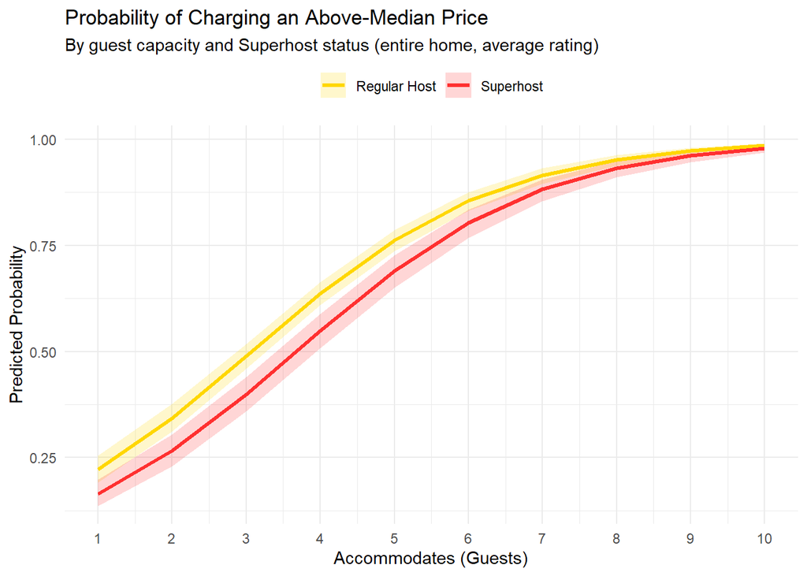

```r
# Build a prediction grid: vary accommodates and superhost, hold the rest constant
d.glm_predict <- expand.grid(
  accommodates         = seq(1, 10, by = 1),
  host_is_superhost    = c(TRUE, FALSE),
  room_type            = "Entire home/apt",
  review_scores_rating = mean(d.airbnb_listings_feat$review_scores_rating, na.rm = TRUE)
)

# Predict on the link scale to also get standard errors, then transform back
glm.pred <- predict(glm.binomial, newdata = d.glm_predict, type = "link", se.fit = TRUE)
d.glm_predict$prob <- plogis(glm.pred$fit)
d.glm_predict$prob_lower <- plogis(glm.pred$fit - 1.96 * glm.pred$se.fit)
d.glm_predict$prob_upper <- plogis(glm.pred$fit + 1.96 * glm.pred$se.fit)

p.glm_binomial <- ggplot(d.glm_predict, aes(
  x = accommodates, y = prob,
  color = host_is_superhost, fill = host_is_superhost
)) +
  geom_ribbon(aes(ymin = prob_lower, ymax = prob_upper), alpha = 0.2, color = NA) +
  geom_line(size = 1.2) +
  scale_x_continuous(breaks = 1:10) +
  scale_color_manual(
    values = c("gold", "firebrick1"),
    labels = c("Regular Host", "Superhost")
  ) +
  scale_fill_manual(
    values = c("gold", "firebrick1"),
    labels = c("Regular Host", "Superhost")
  ) +
  labs(
    title = "Probability of Charging an Above-Median Price",
    subtitle = "By guest capacity and Superhost status (entire home, average rating)",
    x = "Accommodates (Guests)",
    y = "Predicted Probability",
    color = NULL, fill = NULL
  ) +
  theme(legend.position = "top")

p.glm_binomial
```

## 9.4 Interpretation GLM Binomial

The control variables behave as expected: each additional guest nearly doubles the odds of being in the upper price half (OR = 1.834), private and shared rooms are far less likely to land above the median, and a one-point increase in rating raises the odds by about 62%. The hotel-room coefficient is significant but its wide confidence interval (1.259 to 40.642) reflects how few hotel listings are in the dataset.

This is the opposite of what H1 would predict. Superhost status does not raise willingness to pay, it correlates with charging less. Combined with out Reslut in the Quasi-Poisson GLM (Superhosts get 2.6× more bookings), the picture is consistent: Superhosts compete on price and earn through volume, not through a price premium. The practical takeaway for hosts aiming for the badge is to price competitively and let occupancy do the work.

## 9.5 Limitations

- **Median split is rough**. A listing one dollar above the median counts the same as one 500 dollar above. The LM and GAM handle this gradient much better.
- **No location**. We left location out to keep the focus on host variables, but in Vaud, location might be a major price driver. Some of what we attribute to room type or capacity is probably picking up location indirectly.
- **The cutoff moves with the market**. The median is just our sample’s median. If the market shifts, so does it.

# 10 Generalized additive model

## 10.1 Theory

A standard linear model assumes that every predictor moves the price at a constant rate. For Airbnb data that’s almost never true. A Generalized Additive Model (GAM) replaces the fixed coefficients with smooth functions that the model learns from the data, each predictor gets its own curve instead of a single slope. The result stays more interpretable than a Random Forest or Neural Network: every smooth term can be plotted and read like a coefficient.

Three things make a GAM the right fit here:

1. **Price effects are non-linear.** Going from 2 to 4 guests roughly doubles the price; going from 8 to 10 barely moves it. A linear model averages these curves and gets both ends wrong.
2. **Location is non-linear by nature.** Vaud combines lakeshore towns, urban centres, alpine resorts and rural areas, each with their own price logic. A 2D smoother over *longitude* and *latitude* captures this surface without us engineering postcode dummies.
3. **Interpretability stays.** Each smooth term can be plotted on its own and read like a coefficient.

The GAM speaks to **H2** through the spatial spline `s(longitude, latitude)`, while controlling for *host_is_superhost* and *review_scores_rating*.

## 10.2 Model

We start by reducing the dataset to the columns the GAM needs and dropping incomplete rows. The split happens *before* any model is fitted. The same training set will be reused by the SVM to label its traffic-light targets, which prevents information from the GAM leaking into the SVM’s evaluation.

```r
# Data preparation: keep only variables used in the GAM, drop rows with NAs
d.airbnb_listings_feat_gam <- d.airbnb_listings_feat %>%
  select(
    price, accommodates, review_scores_rating,
    number_of_reviews, longitude, latitude,
    room_type, host_is_superhost, bathrooms
  ) %>%
  na.omit()

# Train/test split BEFORE fitting the model.
# This matters for the SVM later, which uses GAM labels — splitting first prevents leakage.
set.seed(42)
n <- nrow(d.airbnb_listings_feat_gam)
train.idx <- sample(seq_len(n), size = floor(0.8 * n))

d.train <- d.airbnb_listings_feat_gam[train.idx, ]
d.test <- d.airbnb_listings_feat_gam[-train.idx, ]
```

After the split, we model `log_price` rather than the raw price. The distribution is heavily right-skewed (see Chapter EDA). Coefficients on the log scale read multiplicatively: β corresponds to roughly `$(exp(β) − 1) × 100%$` price change. We use `method = "REML"` because it gives more reliable confidence intervals than the default.

```r
gam.main <- gam(
  log(price) ~
    s(accommodates) +
    s(review_scores_rating) +
    s(log1p(number_of_reviews)) +
    s(longitude, latitude) +
    room_type +
    host_is_superhost +
    bathrooms,
  family = gaussian(),
  method = "REML",
  data = d.train
)

tidy(gam.main) %>%
  kable(booktabs = TRUE, digits = 3, caption = "GAM: Parametric Coefficients") %>%
  kable_styling() %>%
  footnote(
    general = paste0(
      "Training data (80%): ", nrow(d.train), "\n",
      "Test data (20%): ", nrow(d.test)
    ),
    general_title = "Dataset split"
  )
```

| term | edf | ref.df | statistic | p.value |
| --- | --- | --- | --- | --- |
| s(accommodates) | 4.577 | 5.567 | 117.850 | 0 |
| s(review_scores_rating) | 2.999 | 3.752 | 6.096 | 0 |
| s(log1p(number_of_reviews)) | 2.634 | 3.290 | 40.071 | 0 |
| s(longitude,latitude) | 24.933 | 27.971 | 12.383 | 0 |

Dataset split  
Training data (80%): 2527 Test data (20%): 632

## 10.3 Visualisation

The partial effect plots are the main reason to choose a GAM. Each smooth term is shown on its own, with the shaded area representing the 95% confidence band. We also fit an LM on the exact same data and predictors as a fair benchmark, the only difference is the absence of smooth terms.

The three 1D smooth terms are shown below. The 2D spatial spline `s(longitude, latitude)` is more meaningful as a geographic surface than as an abstract contour plot. We visualise it later in the interactive map. Its EDF still appears in the summary table beside the plots.

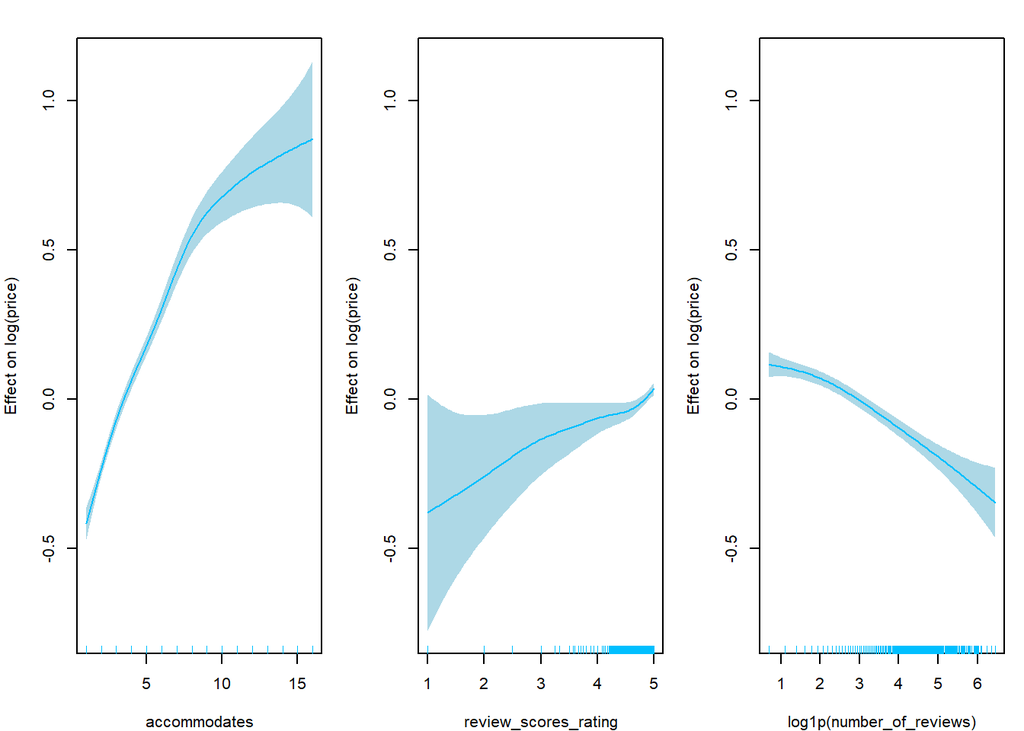

```r
# Partial effect plots for the 1D smooth terms.
# The 2D spatial spline s(longitude, latitude) is shown in the interactive map below.
par(mfrow = c(1, 3), mar = c(4, 4, 2, 1))
plot(gam.main,
  select = 1, shade = TRUE,
  col = "deepskyblue", shade.col = "lightblue",
  seWithMean = TRUE, ylab = "Effect on log(price)"
)
plot(gam.main,
  select = 2, shade = TRUE,
  col = "deepskyblue", shade.col = "lightblue",
  seWithMean = TRUE, ylab = "Effect on log(price)"
)
plot(gam.main,
  select = 3, shade = TRUE,
  col = "deepskyblue", shade.col = "lightblue",
  seWithMean = TRUE, ylab = "Effect on log(price)"
)
```

```r
par(mfrow = c(1, 1))

# EDF table for ALL smooth terms (incl. the 2D spatial spline)
d.table <- as.data.frame(summary(gam.main)$s.table) %>% round(3)
kable(d.table,
  booktabs = TRUE,
  caption = "Smooth Terms: Estimated Degrees of Freedom (EDF)"
) %>%
  kable_styling() %>%
  footnote(
    general = paste0(
      "R-squared: ", round(summary(gam.main)$r.sq, 3),
      ", Deviance explained: ", round(summary(gam.main)$dev.expl, 3)
    ),
    general_title = ""
  )
```

Smooth Terms: Estimated Degrees of Freedom (EDF)

|  | edf | Ref.df | F | p-value |
| --- | --- | --- | --- | --- |
| s(accommodates) | 4.577 | 5.567 | 117.850 | 0 |
| s(review_scores_rating) | 2.999 | 3.752 | 6.096 | 0 |
| s(log1p(number_of_reviews)) | 2.634 | 3.290 | 40.071 | 0 |
| s(longitude,latitude) | 24.933 | 27.971 | 12.383 | 0 |

R-squared: 0.658, Deviance explained: 0.664

To know whether the smooth terms actually buy us something, we fit a linear model on the exact same data and predictors. The only difference is the absence of smoothing terms. R² and AIC together tell us whether the GAM’s added flexibility is worth the additional degrees of freedom. As the GAM has an higher R-Squared and lower AIC, we can say, that it is indeed worth the additional degrees of freedom.

```r
# Fair LM benchmark (same target, same training data)
lm.gam_comparison <- lm(
  log(price) ~ accommodates + review_scores_rating +
    log1p(number_of_reviews) + longitude + latitude +
    room_type + host_is_superhost + bathrooms,
  data = d.train
)

aic_vals <- AIC(lm.gam_comparison, gam.main)
tibble(
  Model = c("LM", "GAM"),
  `R²` = c(
    round(summary(lm.gam_comparison)$r.squared, 3),
    round(summary(gam.main)$r.sq, 3)
  ),
  AIC = round(aic_vals$AIC, 1)
) %>%
  kable(booktabs = TRUE, caption = "Model Comparison: LM vs GAM (same data, same target)") %>%
  kable_styling()
```

Model Comparison: LM vs GAM (same data, same target)

| Model | R² | AIC |
| --- | --- | --- |
| LM | 0.607 | 2599.1 |
| GAM | 0.658 | 2279.5 |

### 10.3.1 Traffic Light Map

The GAM predicts an expected price for every listing. Comparing actual to expected gives hosts a quick verdict: `Underpriced`, `Fair Price`, or `Overpriced`. We set the threshold at ±15%, anchored in the residual standard deviation on the log scale (exp(σ) − 1 ≈ 15%); a stricter or looser band would shift the proportions accordingly.

```r
# Predictions on log scale
d.train$fitted_logprice <- as.numeric(predict(gam.main, newdata = d.train))
d.test$fitted_logprice <- as.numeric(predict(gam.main, newdata = d.test))

# Smearing correction (Duan 1983) for back-transforming log predictions
sigma2 <- summary(gam.main)$scale
smearing <- exp(sigma2 / 2)
d.train$fitted_price <- exp(d.train$fitted_logprice) * smearing
d.test$fitted_price <- exp(d.test$fitted_logprice) * smearing

# Apply traffic-light rule consistently to train and test
make.traffic_light <- function(price, fitted, threshold = 15) {
  pct <- (as.numeric(price) - as.numeric(fitted)) / as.numeric(fitted) * 100
  case_when(
    pct <= -threshold ~ "Underpriced",
    pct >= threshold ~ "Overpriced",
    TRUE ~ "Fair Price"
  ) %>% as.factor()
}

d.train$pct_diff <- (d.train$price - d.train$fitted_price) / d.train$fitted_price * 100
d.test$pct_diff <- (d.test$price - d.test$fitted_price) / d.test$fitted_price * 100
d.train$traffic_light <- make.traffic_light(d.train$price, d.train$fitted_price)
d.test$traffic_light <- make.traffic_light(d.test$price, d.test$fitted_price)

data.frame(
  Set = c("Training", "Test"),
  Underpriced = c(
    round(mean(d.train$traffic_light == "Underpriced") * 100, 1),
    round(mean(d.test$traffic_light == "Underpriced") * 100, 1)
  ),
  Fair = c(
    round(mean(d.train$traffic_light == "Fair Price") * 100, 1),
    round(mean(d.test$traffic_light == "Fair Price") * 100, 1)
  ),
  Overpriced = c(
    round(mean(d.train$traffic_light == "Overpriced") * 100, 1),
    round(mean(d.test$traffic_light == "Overpriced") * 100, 1)
  )
) %>%
  kable(booktabs = TRUE, caption = "Traffic Light Distribution (%): Train vs Test") %>%
  kable_styling()
```

Traffic Light Distribution (%): Train vs Test

| Set | Underpriced | Fair | Overpriced |
| --- | --- | --- | --- |
| Training | 41.4 | 32.8 | 25.9 |
| Test | 42.1 | 33.1 | 24.8 |

The split is stable across train and test. If it weren’t, we’d worry about overfitting. The notable share of “Underpriced” listings is the most actionable finding, which indicates that many hosts are pricing below what the GAM considers the market value.

### 10.3.2 Interactive Map of Vaud

The map below plots every listing in the dataset, coloured by its traffic-light verdict. Click any point to see the actual price, the GAM-recommended price, and the percentage deviation. The clusters of orange “underpriced” points along Lake Geneva and around Lausanne hint at where the recommendation tool would have the biggest immediate impact.

```r
d.map <- bind_rows(d.train, d.test)
color_map <- c(
  "Underpriced" = "#EF9F27",
  "Fair Price" = "#1D9E75",
  "Overpriced" = "#D85A30"
)
d.map$marker_color <- color_map[as.character(d.map$traffic_light)]

leaflet() %>%
  addProviderTiles(providers$CartoDB.Positron) %>%
  setView(lng = 6.65, lat = 46.52, zoom = 9) %>%
  addCircleMarkers(
    data = d.map,
    lng = ~longitude, lat = ~latitude,
    radius = 4, fillColor = ~marker_color,
    fillOpacity = 0.85, stroke = FALSE,
    popup = ~ paste0(
      "<b>Host Verdict:</b> ", traffic_light, "<br>",
      "<b>Actual Price:</b> CHF ", round(price), "<br>",
      "<b>GAM Recommended:</b> CHF ", round(fitted_price), "<br>",
      "<b>Difference:</b> ", round(pct_diff, 1), "%"
    )
  ) %>%
  addLegend(
    position = "bottomright",
    colors   = color_map,
    labels   = c("Underpriced (Increase)", "Fair Price (±15%)", "Overpriced (Decrease)"),
    title    = "Pricing Strategy vs. Market (GAM)",
    opacity  = 0.85
  )
```

[interactive chart not shown]

```r
# Note: d.train and d.test are passed on to the SVM block.
```

## 10.4 Interpretation GAM

The GAM explains 66.4% of the deviance (R² = 0.658) on 2,527 training listings. That’s a clear gain over the LM benchmark (R² = 0.607), and the AIC drops from 2,599 to 2,279 which also suggests a better working Model. The smooth terms earn their additional degrees of freedom.

**Traffic light distribution**. Consistent across train and test (Fair ≈ 33%, Underpriced ≈ 41%, Overpriced ≈ 26%). The overweight of underpriced listings suggests that a notable share of hosts is leaving money on the table.

## 10.5 Limitations

The GAM is the strongest model in this study, but two GAM-specific points are worth keeping in mind:

- **±15% is a chosen threshold**. The traffic-light band is anchored in the residual SD on the log scale, which makes it defensible, but it’s still a choice. Prediction intervals from the GAM directly, or empirical residual quantiles, would be a more rigorous alternative.
- **Spatial spline describes, doesn’t explain**. It fits the price surface very well but doesn’t tell us *why* certain locations are expensive. For a pricing tool that’s enough; for causal claims (does proximity to the lake cause higher prices, or just correlate with better properties?) it isn’t.

# 11 Support vector machine

## 11.1 Theory

A Support Vector Machine separates classes by drawing the widest possible margin between them. We use a radial kernel. This allows us to define the hyperplane more precisely. As a result, with SVM we do not obtain a coefficient that can be interpreted, but rather a model that enables us to predict which group an observation will fall into. In the following model, we apply exactly that. We look at the traffic light groups defined in the GAM-chapter and try to predict, using the available variables, which group a location will fall into. By splitting the data into a training and test dataset, we enable ourselves to test the model, with the drawback that we lose a portion of the training data.

With the SVM, we are not testing any of the hypotheses, but rather the second research question: to what extent can we predict whether the prices of a rental property are justified? The GAM generates a fair market price for each rental property. The SVM, on the other hand, examines whether the current rental prices are justified.

## 11.2 Model

```r
# Setting a seed ensures reproducibility.
set.seed(42)

# Define the relevant columns for the SVM model.
# We include 'price' because the use case requires evaluating if a
# *given* price for a specific set of features is Overpriced, Fair, or Underpriced.
svm.coloums <- c(
  "traffic_light", "price", "accommodates", "review_scores_rating",
  "number_of_reviews", "room_type", "host_is_superhost"
)

# Creating the 80% Training and 20% Test datasets
d.svm_train <- d.train[, svm.coloums]
d.svm_test <- d.test[, svm.coloums]

# We use 10-fold cross-validation to find the optimal 'cost' and 'gamma' parameters
# for the radial kernel.

# tuned_svm <- tune(
#   svm,
#   traffic_light ~ ., # 'traffic_light' was already converted to a factor in the GAM step
#   data = d.svm_train,
#   kernel = "radial",
#   ranges = list(
#     cost = 2^(-6:10),
#     gamma = 2^(-5:2)
#   )
# )

# Extracting the best parameters found during cross-validation
# svm_model_cost <- as.numeric(tuned_svm$best.parameters["cost"])
# svm_model_gamma <- as.numeric(tuned_svm$best.parameters["gamma"])

### einschub!!!!!!
svm_model_cost <- 256
svm_model_gamma <- 0.625


# displaying Parameters for visual confirmation
# cat("Optimal Cost:", svm_model_cost, "\n")
# cat("Optimal Gamma:", svm_model_gamma, "\n")
# cat("Best Cross-Validation Performance (Error Rate):", round(tuned_svm$best.performance, 4), "\n")


# Training the Support Vector Machine using the optimized parameters
svm.main <- svm(traffic_light ~ .,
  data = d.svm_train,
  kernel = "radial",
  cost = svm_model_cost,
  gamma = svm_model_gamma,
  scale = TRUE
) # Scaling to treat all features equally

# Predicting the traffic light categories on test-data
svm.test_pred <- predict(svm.main, d.svm_test)

# Generating the Confusion Matrix to evaluate classification performance
svm.conf_matrix <- table(Predicted = svm.test_pred, Actual = d.svm_test$traffic_light)

# Calculating overall Accuracy
svm_accuracy <- sum(diag(svm.conf_matrix)) / sum(svm.conf_matrix)

kable(svm.conf_matrix, booktabs = TRUE, escape = FALSE, caption = "SVM Confusion Matrix", align = "lccc") %>%
  kable_styling(bootstrap_options = c("bordered")) %>%
  column_spec(2, background = c("deepskyblue", "maroon1", "maroon1")) %>%
  column_spec(3, background = c("maroon1", "deepskyblue", "maroon1")) %>%
  column_spec(4, background = c("maroon1", "maroon1", "deepskyblue")) %>%
  footnote(general = paste0("SVM Test Accuracy: ", round(svm_accuracy * 100, 2), "% \n", "Training set size: ", nrow(d.svm_train), "\n Test set size: ", nrow(d.svm_test)), general_title = "Information:")
```

SVM Confusion Matrix

|  | Fair Price | Overpriced | Underpriced |
| --- | --- | --- | --- |
| Fair Price | 113 | 43 | 42 |
| Overpriced | 28 | 105 | 5 |
| Underpriced | 68 | 9 | 219 |

Information:  
SVM Test Accuracy: 69.15% Training set size: 2527 Test set size: 632

## 11.3 Interpretion SVM

The tuned SVM with an RBF kernel reaches 69.15% accuracy on the test set. This means the model clearly outperforms chance, which would be 33% for a three-class model.

The main issues arise when classifying *Fair Price*. This makes sense, however, since this is the only class that is bounded both above and below and therefore does not exhibit the significant deviations that can be accounted for in the other two categories. For a company like Airbnb, the accuracy is likely too low to make predictions. However, the model shows that estimation within such classes is fundamentally possible. The second Research Question is therefore not easy to answer. We are able to predict wether a price for a location is justified, the accuracy is just not good enough for a company as Airbnb.

## 11.4 Limitations

There are a few clear limitations to the model that can be identified right away. The accuracy is too low for a company like Airbnb to provide pricing recommendations to hosts, especially since the category most severely affected is the *Fair Price* category. This leads, in particular, to hosts being incorrectly advised to adjust their prices. Once again, the main cause of the inaccuracy in this model is the location data. We suspect that at the very least, the distance to the nearest city center would have a significant impact on the accuracy of the estimates.

# 12 Artificial neural network

## 12.1 Theory

An Artificial Neural Network learns flexible, non-linear relationships by chaining together layers of weighted nodes. Unlike the LM or GAM, it does not produce readable coefficients, it learns a mapping from inputs to output and treats the rest as internal weights. That makes it powerful but a blackbox. We use the ANN here as a flexibility check: if the easier interpretable GAM already captures most of the signal, the ANN should not gain much from being more flexible. If it does, we are not counting in an important factor.

## 12.2 Model

We use the ANN to revisit H1 from a different angle. The Naive ANN tests whether host-centered variables alone (*review score*, *review count*, *Superhost status*, *capacity*) can predict price. The Expanded ANN adds *room* and *property type* as controls. Comparing the two shows whether any apparent Superhost effect survives.

```r
# Selecting basic variables. We omit missing values for this simplified approach.
d.ann_naive <- d.airbnb_listings_feat %>%
  select(
    price,
    review_scores_rating,
    number_of_reviews,
    host_is_superhost,
    accommodates
  ) %>%
  na.omit()

# Neural Networks perform best (and converge faster) when all input features are scaled to a similar range, typically [0, 1].

normalize <- function(x) {
  return((x - min(x)) / (max(x) - min(x)))
}

# Apply min-max normalization to all columns
d.ann_naive_scaled <- as.data.frame(lapply(d.ann_naive, normalize))

# Train the basic Neural Network
# We use 1 hidden layer with 3 neurons. linear.output = TRUE is used for regression (predicting a continuous price).
set.seed(42)
nn.naive <- neuralnet(
  price ~ review_scores_rating + number_of_reviews + host_is_superhost + accommodates,
  data = d.ann_naive_scaled,
  hidden = 3,
  linear.output = TRUE,
  stepmax = 1e6
)

plot(nn.naive)

# Calculate the mean for our features to represent a "statistically average" Airbnb
mean_rating <- mean(d.ann_naive_scaled$review_scores_rating)
mean_reviews <- mean(d.ann_naive_scaled$number_of_reviews)
mean_acc <- mean(d.ann_naive_scaled$accommodates)

# Create two identical fictional hosts: one is a regular host (0), one is a Superhost (1)
test_data_h3_naive <- data.frame(
  review_scores_rating = c(mean_rating, mean_rating),
  number_of_reviews = c(mean_reviews, mean_reviews),
  host_is_superhost = c(0, 1), # The only difference between the two instances
  accommodates = c(mean_acc, mean_acc)
)

# Predict the scaled prices
predictions_h3_naive <- compute(nn.naive, test_data_h3_naive)

# Reverse the min-max scaling to interpret the results in real CHF
min_price <- min(d.ann_naive$price)
max_price <- max(d.ann_naive$price)
real_prices_naive <- predictions_h3_naive$net.result * (max_price - min_price) + min_price

# print("Predicted Prices (Naive Model): Regular Host vs. Superhost")
# print(real_prices_naive)

# Create a clean dataframe for the table
results.ann_basic <- data.frame(
  "Host_Type" = c("Regular Host (0)", "Superhost (1)"),
  "Predicted_Price_CHF" = round(as.numeric(real_prices_naive), 2)
)
```

```r
# Data Preparation & Dimensionality Reduction
d_model_ready <- d.airbnb_listings_feat %>%
  select(
    price,
    review_scores_rating,
    number_of_reviews,
    host_is_superhost,
    accommodates,
    property_type,
    room_type
  ) %>%
  na.omit() %>%
  # put rare property types into an "Other" category to keep the variable tidy
  mutate(property_type = fct_lump_n(property_type, n = 4, other_level = "Other"))

# One-Hot Encoding: We convert categorical variables into binary dummy variables.
d_dummies <- as.data.frame(model.matrix(~ . - 1, data = d_model_ready))

# Sanitize column names to prevent crashes
colnames(d_dummies) <- make.names(colnames(d_dummies))

d_scaled <- as.data.frame(lapply(d_dummies, normalize))

set.seed(42)
nn.expanded <- neuralnet(
  price ~ .,
  data = d_scaled,
  hidden = 3,
  linear.output = TRUE,
  stepmax = 1e6
)

plot(nn.expanded)

# To conduct a fair "what-if" analysis (Partial Dependence), we take the mean of ALL variables to represent an absolutely "average" listing.
test_data_h3_exp <- as.data.frame(lapply(d_scaled, mean))

# Duplicate the row to create two identical hypothetical listings
test_data_h3_exp <- rbind(test_data_h3_exp, test_data_h3_exp)

# Isolate the Superhost effect: Row 1 = Regular Host, Row 2 = Superhost
test_data_h3_exp$host_is_superhostFALSE <- c(1, 0)
test_data_h3_exp$host_is_superhostTRUE <- c(0, 1)

# Predict prices (excluding the 'price' column from the input)
predictions_h3_exp <- compute(nn.expanded, test_data_h3_exp %>% select(-price))

# Reverse scaling using the min/max from the unscaled dataset
min_price_exp <- min(d_model_ready$price)
max_price_exp <- max(d_model_ready$price)

real_prices_expanded <- predictions_h3_exp$net.result * (max_price_exp - min_price_exp) + min_price_exp

# print("Predicted Prices (Expanded Model): Regular Host vs. Superhost")
# print(real_prices_expanded)

results.df_exp <- data.frame(
  "Host_Type" = c("Regular Host (0)", "Superhost (1)"),
  "Predicted_Price_CHF" = round(as.numeric(real_prices_expanded), 2)
)
```

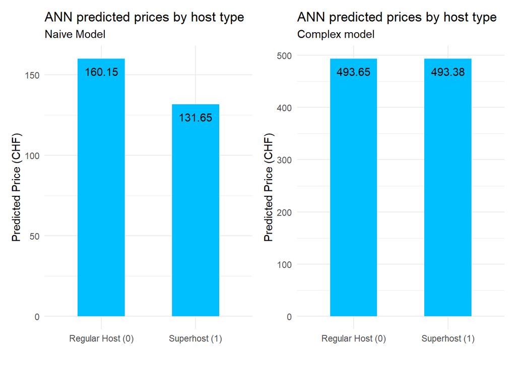

```r
p.ANN_basic <- ggplot(results.ann_basic, aes(Host_Type, Predicted_Price_CHF)) +
  geom_col(fill = "deepskyblue", width = 0.5) +
  geom_text(aes(label = round(Predicted_Price_CHF, 2)),
    vjust = 2
  ) +
  labs(
    title = "ANN predicted prices by host type",
    subtitle = "Naive Model",
    x = " ",
    y = "Predicted Price (CHF)"
  )

p.ANN_complex <- ggplot(results.df_exp, aes(Host_Type, Predicted_Price_CHF)) +
  geom_col(fill = "deepskyblue", width = 0.5) +
  geom_text(aes(label = round(Predicted_Price_CHF, 2)),
    vjust = 2
  ) +
  labs(
    title = "ANN predicted prices by host type",
    subtitle = "Complex model",
    x = " ",
    y = "Predicted Price (CHF)"
  )

p.ANN_basic | p.ANN_complex
```

## 12.3 Interpretation ANN

Our initial Neural Network predicted price using only review metrics, listing capacity, and Superhost status. Surprisingly, it priced Superhosts lower (**131.65 CHF**) than regular hosts (**160.15 CHF**). This was a clear case of omitted variable bias: Superhosts often use competitive pricing to maintain the high occupancy required for the badge, while expensive luxury rentals are usually managed by agencies that don’t hold Superhost status.

We corrected this in a second model by adding room and property types, using One-Hot Encoding to convert these categories into numerical inputs. Once we controlled for these structural factors to compare similar listings, the price gap practically vanished (**493.38 CHF** for Superhosts vs. **493.65 CHF** for regular hosts). This refutes our initial hypothesis: when comparing apples to apples, Superhost status alone does not significantly increase a guest’s willingness to pay. Superhosts often achieve their high status through competitive pricing strategies designed to maximize occupancy rather than nightly margins. Ultimately, a guest’s willingness to pay is dictated almost entirely by physical listing attributes like *accommodates*, *room_type*, and *property_type*. Therefore, we advise hosts to anchor their pricing strictly to their property’s structural features, leveraging their Superhost badge purely as a marketing tool to capture market share and drive booking volume.

## 12.4 Limitations

A primary limitation of the `nn_expanded model` is the inherent “black box” nature of Artificial Neural Networks, which drastically reduces the interpretability of individual price drivers compared to transparent linear models. Because neural networks require mathematical normalization, calculating the exact monetary impact of isolated variables like *review_scores_rating* is complex and requires continuous reverse-scaling. Furthermore, while we corrected for some omitted variable bias by using One-Hot Encoding for property categories, the model still lacks precise geospatial data, meaning the massive price impact of specific, highly desirable neighborhoods remains uncaptured. Testing our hypothesis also relied on creating a mathematically “average” hypothetical listing, which may not perfectly reflect the nuanced reality of distinct luxury or budget segments in the Canton of Vaud. Finally, applying the na.omit() function removed listings with incomplete profiles, which could introduce bias if those missing data points systematically represented a specific market segment, such as poorly managed properties.

# 13 Conclusion

## 13.1 Scientific Conclusion

### 13.1.1 Answering research questions

To answer the *first research question* we have to analyse our answers to both of the hypothesis.

in terms of host-sided Variables (H1) we find that**The Superhost badge does not raise the nightly price**. Four models with completely different mechanics, the linear regression, the logistic regression (GLM Binomial), the spline-based GAM, and the neural network, all return the same answer: after controlling for listing size, room type and other structural features, Superhost status has no measurable positive effect on price. Some models even show a small *negative* effect. This is the most robust single finding in this study. We can conclude thath Superhost strategy is: pricecompetitively, earn through volume.

A contrast worth highlighting is the Naive ANN versus the Expanded ANN. The naive version, trained only on host variables, predicts a *lower* price for Superhosts (**131.65 CHF** vs. **160.15 CHF**). Once room and property type are added, the gap collapses to less than a dollar. This isn’t really a disagreement between models but a useful warning against drawing conclusions from raw price comparisons.

The answer to the first research question is, accordingly, relatively straightforward. We find that virtually all of the variables we examined have an impact on pricing. Interestingly, Superhost status has a negative impact. Furthermore, we find that venue-oriented variables, in particular, have a strong influence.

To answer the *second research question*, we must refer to the results of the support vector machine. We see that it is possible to predict the fairness of the price, but we also recognize that this prediction is insufficient based on the variables available to us. 69.15% accuracy is just no good enough to criticize hosts for their pricing.

### 13.1.2 Overall Limitations

Five limitations apply to this entire study, not just to individual models:

**Snapshot, no time component**. All models are trained on a single point in time. Seasonal pricing, weekday effects, and event-driven demand spikes (Montreux Jazz Festival, ski season, weekends) are nowhere in the data. The recommendations represent an *average* market price, not a dynamic one. A real production pricing tool would need a time dimension we don’t have.

**Listed price as a proxy for willingness to pay**. We treat what hosts charge as a proxy for what guests would pay. This holds on average across a large sample, but it breaks down for listings that sit unbooked at their current price, those listings still shape the model and probably tilt it slightly toward optimistic price levels. A true willingness-to-pay study would need booking data, completed transactions, and ideally A/B tests of competing prices.

**Missing predictors.** Photo quality, amenity counts, listing description sentiment, view from the property, noise levels, distance to public transport, none of this is in the dataset. Some of the unexplained variance (around a third for the GAM) lives in these omitted variables rather than in any model’s limitation.

**Reverse causality.** Several relationships in our data probably flow in both directions. More bookings produce more reviews, which make Superhost status easier to maintain, which probably increases visibility, which leads to more bookings. None of our models can untangle which effect causes which. For descriptive purposes that’s fine, but the recommendations should be read as “what works on average,” not “what works because of X.”

**Vaud-specific.** The dataset covers one Swiss canton at one point in time. The price levels, location dynamics (lakeshore premium, alpine resorts), and host behaviours are specific to this market. The methodology transfers; the exact coefficients do not. Applying the same models to Geneva or Bern would require refitting on local data.

### 13.1.3 Next Steps

When we put the results of the study and the identified limitations into context, we realize that there is plenty of room for future research. We were able to see that a generalized additive model is a very useful approach. However, we have a clear shortcoming, particularly with regard to the limitation of location. Especially if there is a meaningful operationalization of location, for example, based on distances to a city center—pricing can be addressed in even greater detail. This would benefit not only the GAM but all models. However, our study demonstrated what is fundamentally possible. Regarding the second research question and the support vector machine, we also recognize that price classification is both possible and useful. Therefore, we see massive potential for Airbnb in this area in particular, which could be explored in a future study. Further improvements are also possible if the dataset were expanded to include additional Swiss cantons or other parts of the world.

## 13.2 Businesscase conclusion

### 13.2.1 Recommendations for Hosts

For hosts setting or revising their nightly price:

- **Anchor on structure, not status**. What a guest actually pays for is the listing itself: room type, capacity, bathrooms, location. The Superhost badge helps with visibility and booking volume, not with the per-night rate.
- **Use the traffic-light tool as a sanity check, not a target**. The GAM-based recommendation gives a fair-market range based on what comparable listings achieve. A listing flagged “Underpriced” is leaving money on the table; one flagged “Overpriced” risks sitting empty.
- **If you’re building toward Superhost status, compete on price**. The 2.6× occupancy boost comes from satisfied guests and a full calendar. Premium pricing makes both harder. Start with competitive pricing, accumulate reviews, then raise prices selectively once the badge is secure.
- **Review scores matter less than you think for price**. Across the pricing models the reward for higher ratings is modest. Reviews matter, but their role is to drive *bookings*.

### 13.2.2 Recommendations for Airbnb

For the platform itself, the same data points in three directions:

- **A pricing assistant should use the GAM, not a linear formula**. Linear or postcode-based tools will systematically underprice lakeshore listings and overprice rural ones. The 2D spatial spline is the most defensible way to capture local dynamics with the data Airbnb already collects.
- **Coach the “Underpriced” segment**. Roughly 41% of listings in the dataset sit below the GAM’s fair-price band. These hosts are the easiest group to help: a recommendation alone could shift their pricing toward market value, lifting both host revenue and platform commission.
- **Add operationalised location features**. Raw coordinates work well for a smoother like the GAM but limit simpler tools. Distance to the nearest lake, city centre, ski lift, and public transport stop would let classifiers like the SVM catch up to the GAM’s accuracy — and these features are trivial to compute centrally and serve to every model on the platform.

# 14 Lessons learned

## 14.1 Pascal

Working on this project was a huge reality check in the best way possible. In our classes, we are used to getting “perfect” datasets that are practically made for the specific algorithms we are learning. But working with our actual `d.airbnb_listings_feat` dataset showed me how much effort actually goes into data cleaning and prepping before you can even start modeling. I personally focused on building the GLM-Poisson and ANN models, and trying to get them to perform well on real, messy data required a lot more critical thinking and trial-and-error than our standard assignments in class.

Since we split up the workload, I didn’t code every single model myself. Instead, my role for the LM, GLM-Binomial, GAM, and SVM models was to check and review the work of my team members. This turned out to be a super valuable learning experience on its own. Reading through their code allowed me to see exactly how other people translate what we learned in class into practice. Seeing their different approaches to problem-solving and troubleshooting bugs really helped expand my own coding mindset.

Finally, figuring out how to collaborate effectively on code was a massive win for us. We used GitHub with RStudio for the first time, and it honestly made a world of difference. We finally found a setup that actually works for coding together as a group, which saved us a lot of headaches and is definitely a workflow I’ll be taking into future projects.

## 14.2 Timon

I was already familiar with RStudio from my bachelor’s program, and I’d had very positive experiences with it so far and I feel very comfortable using it. Up until now, however, I’ve mainly worked with simple linear models and generalized linear models. Everything else was new to me. In this project, I focused primarily on support vector machines, and I’m very impressed by the concept because it’s both very simple and yet involves a tremendous amount of complexity. Working with this model in particular was a key learning experience for me.

Another key learning was the SCRUM-like structuring of the work process. Within the document, we work with a list of tasks to be completed by the next meeting and a backlog of tasks that we can’t tackle right now but know are coming up. This worked very well for us. It provided a sense of accountability to ensure all tasks were completed effectively.

Finally, working with GitHub on this scale was also fairly new to me. We used the integration with RStudio for the first time, and I’m personally thrilled by how simple it is. We had almost no issues with incorrect versions, even though we weren’t working with separate branches. I think, however, that splitting up the models really helped us in that regard.

## 14.3 Davide

Coming into this project, my comfort zone was firmly in theory. I knew what a GLM was on paper, but actually building one that holds up against messy data was a different exercise. Working on the GLM Binomial and GAM forced me to confront the gap between understanding a model and making it useful. Things that look elegant in a lecture slide turn out to require dozens of small judgement calls in practice: which variables to include, how to handle NAs, when to log-transform, where to draw a threshold.

The GAM was probably my biggest single learning. I had never worked with smooth terms before, and seeing the 2D spatial spline pick up Vaud’s geography was genuinely a moment where the theory clicked into practice.

Another lesson, less technical but probably the most useful one, was around our several iterations and the extra miles we took. I rewrote most of my texts at least three times. Each round made them shorter, clearer, and less **AI-flavoured**. I went into this project assuming the modelling would be the hard part. By the end, communicating the results clearly turned out to be just as much work.

Finally, R Bootcamp in February laid the foundation, but this project was where I actually got comfortable. Reading the others’ code, debugging together, learning shortcuts — that side-by-side learning was something I can’t get from a tutorial.

# 15 Use of GenAI

Throughout this machine learning project, we leveraged various Generative AI tools specifically ChatGPT, Gemini, and Claude to support our analytical workflow. A primary use case was troubleshooting complex issues that extended beyond our existing knowledge base. When encountering technical bottlenecks, we used these models to break down and explain the underlying concepts, enabling us to systematically find the right solutions. Furthermore, we utilized GenAI as a critical review mechanism for our modeling approach. We consulted the AI to verify whether we had made the appropriate theoretical assumptions, such as selecting the correct data distributions for our models. It also served as a valuable sounding board to double-check our final analytical interpretations, ensuring our conclusions were statistically sound. Finally, these tools provided essential linguistic support. We actively used GenAI to translate our documentation and findings into professional English, ensuring a high-quality final report.